# CopiaLIMPIA_M2_883_RL_PEC2_AlexRuzafa

[figure not shown]

M2.883 · Aprendizaje por refuerzo

2025-1 · Máster universitario en Ciencia de datos (*Data science*)

Estudios de Informática, Multimedia y Telecomunicación

# PEC2: Deep Reinforcement Learning

En esta práctica se implementarán modelos de DRL en un entorno diseñado por el alumno, con el objetivo de analizar distintas formas de aprendizaje de un agente y estudiar su rendimiento. El agente será entrenado con los métodos:

1. DQN
2. Dueling DQN
3. Double DQN

En esta práctica implementaremos los diferentes métodos de aprendizaje por refuerzo vistos en la **Unidad III: Soluciones Aproximadas**. En concreto, nos centraremos en la implementación de un entorno e implementaremos los diferentes métodos para buscar una solución óptima del problema.

Consideraciones generales:

- Esta PEC debe realizarse de forma **estrictamente individual**. Cualquier indicio de copia será penalizado con un suspenso (D) para todas las partes implicadas y la posible evaluación negativa de la asignatura de forma íntegra.
- Los **resultados** de cada ejercicio deben ser **comentados** ya que dichos comentarios se valorarán con un peso similar en la nota al del código entregado. Para ello se han habilitado una serie de **celdas** que el **alumno debe completar**. Se valorará la **concisión** de los comentarios respondiendo a las preguntas efectuadas.
- Es necesario que el estudiante indique **todas las fuentes** que ha utilizado para la realización de la PEC. De no ser así, se considerará que el estudiante ha cometido plagio, siendo penalizado con un suspenso (D) y la posible evaluación negativa de la asignatura de forma íntegra. Para ello se ha habilitado una **celda** correspondiente en cada ejercicio que el **alumno debe completar** para que el ejercicio sea **evaluado**. NOTA: Si en la realización de un ejercicio no se ha hecho uso de ninguna fuente también se debe indicar para que el ejercicio sea evaluado.
- Si se hace uso de cualquier **IA generativa** en la resolución de la PEC esta **debe referenciarse** en aquellos apartados donde se haya utilizado, como cualquier otra fuente (indicando el/los modelo/os de IA utilizado/os). En cualquier caso, se presupone su uso como el de cualquier otra fuente y se asume que, si el alumno la utiliza, es con el conocimiento pleno de lo que genera y entrega.
- El PDC se reserva el derecho de realizar una **sesión de consultas síncrona** con cualquier alumno (via Google Meet o similar) si existe duda sobre el uso de las fuentes utilizadas, con el fin de poder **evaluar los conocimientos mostrados en la PEC**.

Formato de la entrega:

- Algunos ejercicios pueden suponer varios minutos de ejecución, por lo que la entrega debe hacerse en **formato notebook** y en **formato html**, donde se vea el código, los resultados y comentarios de cada ejercicio. Se puede exportar el notebook a HTML desde el menú File $\to$ Download as $\to$ HTML.
- Existe un tipo de celda especial para albergar texto. Este tipo de celda os será muy útil para responder a las diferentes preguntas teóricas planteadas a lo largo de la actividad. Para cambiar el tipo de celda a este tipo, en el menú: Cell $\to$ Cell Type $\to$ Markdown.

**Recordatorio: Verificación de autoría mediante entrevista de contraste**

Esta actividad está sujeta a la verificación de la autoría, la cual puede incluir entrevistas de contraste, tal como se describe en el plan docente de la asignatura. En caso de que el profesorado lo considere necesario, se podrá convocar al estudiante para realizar una entrevista con el objetivo de comprobar la correspondencia entre el contenido presentado y los conocimientos adquiridos, así como la autoría independiente de la actividad.

Encontraréis más información en el plan docente de la asignatura.

## 0 Contexto

El aprendizaje por refuerzo es un campo de la inteligencia artificial que busca desarrollar sistemas capaces de aprender y tomar decisiones autónomas a través de la interacción con su entorno. A lo largo de los años, este enfoque ha demostrado su eficacia en ámbitos muy diversos, desde juegos clásicos hasta robótica o control de sistemas complejos. Sin embargo, uno de los principales retos del aprendizaje por refuerzo consiste en diseñar entornos de simulación adecuados que representen de forma precisa la dinámica de la tarea que se desea abordar.

En este contexto, esta PEC tiene como objetivo desarrollar un nuevo entorno de simulación denominado **Pong en la pared**, inspirado en el clásico juego Pong, pero modificado para que solo intervenga un jugador. En este entorno, el agente debe controlar una pala que rebota una pelota contra una pared, intentando mantener el juego activo el mayor tiempo posible y evitar que la pelota se escape. De este modo, el entorno permite experimentar con diferentes algoritmos de aprendizaje por refuerzo aplicados a tareas de control continuo, percepción y toma de decisiones en tiempo real.

Para ello, se implementará el entorno siguiendo las especificaciones de Gymnasium (https://gymnasium.farama.org ), que proporciona una interfaz estándar para la creación de entornos personalizados de aprendizaje por refuerzo. El entorno simulará el comportamiento dinámico del juego, incluyendo la física de rebote de la pelota, la velocidad de movimiento y la penalización por perder el control de la pelota, ofreciendo así una plataforma adecuada para entrenar y evaluar agentes inteligentes

## 1 Creación de un entorno en Gym (3 ptos)

En este ejercicio diseñaremos un entorno sencillo siguiendo el esquema de los entornos de `Gymnasium`, y trataremos de resolverlo.

Los entornos de `Gymnasium` suelen tener la siguiente estructura:

```
class FooEnv(gym.Env):
  metadata = {'render.modes': ['human']}

  def __init__(self):
    ...
  def step(self, action):
    ...
    return new_state, reward, terminated, truncated, info

  def reset(self):
    ...
    return observation, info

  def render(self, mode='human', close=False):
    ...
```

El primer paso será instalar las librerías necesarias para abordar la PEC:

```python
!pip install gymnasium
!pip install torch
!pip install matplotlib
!pip install numpy
!pip install tensorboard
!pip install tdqm
!pip install tabulate
!pip install pandas
```

```
  Preparing metadata (setup.py) ... done
```

y las importamos:

```python
import numpy as np
import gymnasium as gym
import random
import matplotlib.pyplot as plt
from gymnasium.spaces import Discrete, Box
from collections import namedtuple, deque
from copy import deepcopy
import math
import time
import torch
import torch.nn.functional as F
from tabulate import tabulate
import pandas as pd
import warnings
from tqdm.auto import tqdm



warnings.filterwarnings("ignore", category=FutureWarning)
warnings.filterwarnings("ignore", category=DeprecationWarning)

print("Esta PEC ha sido testeada en Google Colab con las versiones siguientes:")
print("Gym Version:", gym.__version__)
print("Torch Version:", torch.__version__)
```

```
Esta PEC ha sido testeada en Google Colab con las versiones siguientes:
Gym Version: 1.2.2
Torch Version: 2.9.0+cu126
```

### 1.0 Entorno de Simulación: Pong en la pared (un solo jugador)

### Entorno de Simulación: *Pong en la pared*

- **Nombre del entorno (clase):** `SimplePongEnv` (registrado como `SimplePong-v0`).
- **Base:** hereda de `gym.Env` y sigue la interfaz Gymnasium (`reset`, `step`, `render`).
- **Zona de juego por defecto:** rejilla discreta de `width=24`, `height=18`, con bordes sólidos.

#### Pala (jugador)

- Ubicada en la columna derecha (`paddle_col = width - 2`).
- Tamaño por defecto `paddle_size=4`.
- Posición vertical limitada al área jugable.

#### Pelota

- Se mueve una celda por paso.
- Velocidad horizontal `vx ∈ {+1, -1}` y vertical `vy ∈ {-1, 0, 1}` con rebotes en techo/suelo/pared izquierda.
- Al impactar en la pala, se refleja (`vx = -1`) y se reasigna un `vy` estable con mayor probabilidad de ±1 que de 0.

#### Espacio de acciones: `Discrete(3)`

- **0** → mover pala **arriba** (–1 celda)
- **1** → **mantener** posición
- **2** → mover pala **abajo** (+1 celda)

#### Espacio de observación

`Box(low=[0,0,0,-1,-1], high=[1,1,1,1,1], dtype=float32)` con 5 características normalizadas:

- `paddle_y_norm` → posición vertical de la pala
- `ball_x_norm` → posición x de la pelota
- `ball_y_norm` → posición y de la pelota
- `vx_norm` → velocidad x de la pelota (en [-1, 1])
- `vy_norm` → velocidad y de la pelota (en [-1, 1])

#### Sistema de recompensas

- **+1.0** al golpear la pelota con la pala (rebote correcto).
- **-1.0** si la pelota supera la pala (fallo) ⇒ episodio *termina*.
- **-0.01** de penalización por paso para incentivar eficiencia (evitar “jugar” indefinidamente sin mejorar).

#### Duración del episodio

- Por defecto `max_steps=2000` (episodio *truncado* si se alcanza).
- Termina antes si el agente falla el rebote (condición de `terminated=True`).

#### Renderizado

Modo `rgb_array` en escala de grises para visualización en Jupyter (campo, pala, pelota y “red” central).

#### Objetivo de aprendizaje

Maximizar la recompensa acumulada por episodio, lo que equivale a mantener la pelota en juego el mayor tiempo posible mediante una colocación y seguimiento eficaces de la pala.

**Nota de implementació (ya presente en tu notebook)**: el entorno se registra como

```
register(
    id="SimplePong-v0",
    entry_point="__main__:SimplePongEnv"
)
```

y se puede instanciar con:

```
env = gym.make(
    "SimplePong-v0",
    render_mode="rgb_array",
    width=24,
    height=18,
    paddle_size=4,
    max_steps=2000
)
```

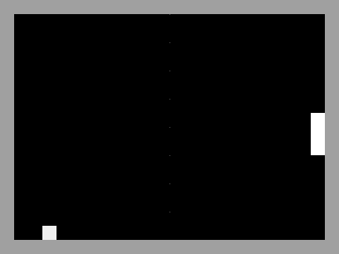

### 1.1 Implementación del entorno SimplePongEnv (Pong en la pared)

**Ejercicio 1.1 (2.25 ptos):** Completa el entorno `SimplePongEnv` siguiendo los **TODO(alumno)** marcados en la celda única del notebook. El entorno debe permitir entrenar un agente que controle una pala situada a la derecha para mantener la pelota en juego el máximo tiempo posible.  
**Objetivo:** Implementar la dinámica del juego, la interfaz Gymnasium y la observación normalizada para que el entorno sea compatible con agentes de aprendizaje por refuerzo.

#### Checklist de TODOs a completar

1. **Espacios de Gymnasium**
   - Definir `action_space = ....`.
   - Definir `observation_space = spaces.Box(...)` con 5 características normalizadas: `[paddle_y_norm, ball_x_norm, ball_y_norm, vx_norm, vy_norm]` y `dtype=np.float32`.
2. **Inicialización del estado (`reset_vars`)**
   - Reiniciar el contador: `self.step_count = 0`.
   - Colocar la pala centrada verticalmente.
   - Colocar la pelota cerca de la pared izquierda (`ball_x = play_min_x + 1`).
   - Asignar `ball_y` aleatorio dentro del área jugable.
   - Fijar `vx = +1` (hacia la pala).
   - Elegir `vy ∈ {-1, 0, 1}` aleatorio.
3. **Reinicio del entorno (`reset`)**
   - Si llega `seed`, re-inicializar el RNG: `self.rng = np.random.default_rng(seed)`.
   - Llamar a `self.reset_vars()`.
   - Devolver la observación inicial y `info` vacío: `return self._obs(), {}` (incluye comentario explicativo).
4. **Paso de simulación (`step`)**
   - Incrementar `self.step_count`.
   - Mover la pala según la acción (0=arriba, 1=quieto, 2=abajo).
   - Limitar la pala con `np.clip` usando `half = (paddle_size-1)//2`.
   - Inicializar `reward = -0.01` y `terminated = False`.
   - Proponer movimiento de la pelota: `nx = ball_x + vx`, `ny = ball_y + vy`.
   - Rebotes:
     - **Techo/suelo:** corregir overshoot y cambiar signo de `vy`.
     - **Pared izquierda:** corregir overshoot y cambiar signo de `vx`.
   - Colisión con la pala (pared derecha):
     - Si la pelota va hacia la derecha y alcanza la columna de la pala, comprobar impacto con el segmento `[y0..y1]`.
     - Si impacta: colocar `nx = paddle_col - 1`, poner `vx = -1`, mantener la reasignación estable de `vy` (ya dada) y sumar **+1.0** a la recompensa.
     - Si falla: `terminated = True` y restar **-1.0**.
   - Actualizar `ball_x`, `ball_y` solo si no ha terminado.
   - Truncado: `truncated = ...`.
   - Return: `return ....`.
5. **Observación normalizada (`_obs`)**
   - Devolver `np.array([py, bx, by, vx, vy], dtype=np.float32)` con posiciones en `[0,1]` y velocidades en `[-1,1]` (ya incluido y comentado).

#### Rúbrica de evaluación (2.25 ptos)

| Criterio | Puntos |
| --- | --- |
| Espacios Gymnasium correctos (rangos y `dtype`) | 0.25 |
| Estado inicial coherente (`reset_vars`) | 0.25 |
| Acciones y *clamp* de la pala | 0.25 |
| Movimiento pelota y rebotes techo/suelo | 0.40 |
| Rebote pared izquierda | 0.20 |
| Colisión con pala y recompensas (+1/-1) | 0.60 |
| Actualización final, `terminated/truncated` y `return` | 0.30 |
| **Total** | **2.25** |

#### Notas y recomendaciones

- El bloque de **render** y la reasignación probabilística de `vy` tras impacto ya están implementados para centrar el ejercicio en la dinámica y la API de Gymnasium.

**Entrega:** sube la celda única con todos los `TODO(alumno)` completados y funcionando.

```python
# ==== CELDA ÚNICA: PONG + VISUAL EN JUPYTER ====
import numpy as np
import gymnasium as gym
from gymnasium import spaces
from gymnasium.envs.registration import register
from IPython.display import display
import matplotlib.pyplot as plt
import time

class SimplePongEnv(gym.Env):
    """
    Pong mínimo, entero por celdas:
      - Tablero con bordes; pala fija a la derecha (columna width-2).
      - La pelota avanza 1 celda por paso: vx∈{+1,-1}, vy∈{-1,0,1}.
      - Rebotes sencillos (sin spin, sin subpasos): no hay 'tunneling'.
      - Estado (5): [paddle_y_norm, ball_x_norm, ball_y_norm, vx_norm, vy_norm]
      - Acciones: 0=arriba, 1=quieto, 2=abajo.
      - Render: "rgb_array" para Jupyter (cuadraditos).
    """
    metadata = {"render_modes": ["rgb_array"], "render_fps": 60}

    def __init__(self, render_mode=None, width=24, height=18, paddle_size=4, max_steps=2000, rgb_scale=16):
        super().__init__()
        assert width >= 10 and height >= 8 and 1 <= paddle_size <= height-4
        self.width = width
        self.height = height
        self.play_min_x, self.play_max_x = 1, width-2
        self.play_min_y, self.play_max_y = 1, height-2
        self.paddle_size = paddle_size
        self.paddle_col = width-2
        self.max_steps = max_steps
        self.rgb_scale = rgb_scale

        # === TODO(alumno): definir espacios Gymnasium ===
        # Discrete(3) para acciones. Box de 5 features normalizadas para observación.
        self.action_space = spaces.Discrete(3)
        self.observation_space = spaces.Box(
            low=np.array([0.0, 0.0, 0.0, -1.0, -1.0], dtype=np.float32),
            high=np.array([1.0, 1.0, 1.0,  1.0,  1.0], dtype=np.float32),
            dtype=np.float32
        )
        #FIN TODO

        self.render_mode = render_mode
        self.rng = np.random.default_rng()
        self.reset_vars()

    def reset_vars(self):

       #  === TODO(alumno):  1) Reinicia el contador de pasos del episodio.
       #    Esto permite aplicar el truncado por longitud (max_steps) y
       #    empezar cada episodio desde cero.
       self.step_count = 0

       #  === TODO(alumno):  2) Coloca la pala centrada verticalmente.
       #    - El área jugable en vertical va de play_min_y a play_max_y.
       #    - Usamos la media entera (//2) para obtener el centro.
       self.paddle_y = (self.play_min_y + self.play_max_y) // 2

       #  === TODO(alumno):  3) Coloca la pelota cerca del borde izquierdo.
       #    - Empezar a la izquierda hace que la pelota "venga hacia la pala"
       #      (que está a la derecha), lo que genera interacción desde el inicio.
       self.ball_x = self.play_min_x + 1

       #  === TODO(alumno):  4) Elige aleatoriamente la coordenada vertical inicial de la pelota.
       #    - Integramos aleatoriedad para que los episodios no sean siempre iguales.
       #    - rng.integers(a, b) devuelve valores en [a, b) (b excluido),
       self.ball_y = self.rng.integers(self.play_min_y, self.play_max_y + 1)

       #  === TODO(alumno):  5) Fija la velocidad horizontal hacia la pala (a la derecha).
       #    - Como la pala está a la derecha, esto garantiza que habrá posibles colisiones.
       self.vx = 1  # hacia la pala

       #  === TODO(alumno):  6) Elige aleatoriamente la velocidad vertical inicial.
       #    - Permitimos -1, 0 o 1 para que la pelota pueda subir, ir recta o bajar.
       #    - Esto añade variedad a la trayectoria desde el primer frame.
       self.vy = int(self.rng.choice([-1, 0, 1]))

    def reset(self, *, seed=None, options=None):
        if seed is not None:
            self.rng = np.random.default_rng(seed)

        #  === TODO(alumno):  Llama a la función auxiliar que reinicia todas las variables del juego:
        #    posición de la pala, pelota y velocidades iniciales.
        self.reset_vars()
        #  === TODO(alumno):  Devuelve el estado inicial del entorno (observación normalizada)
        return self._obs(), {}

    def step(self, action):
         # === TODO(alumno): implementar un paso de simulación ===
         # Esta función se ejecuta en cada frame y devuelve:
         #  - la nueva observación (estado)
         #  - la recompensa obtenida
         #  - si el episodio ha terminado (terminated)
         #  - si se ha truncado por longitud máxima (truncated)
         #  - un diccionario de información (info)

        #  === TODO(alumno): 1) Incrementa el contador de pasos del episodio
        self.step_count += 1

        # 2) Actualiza la posición de la pala según la acción
        #    0 → arriba, 1 → quieto, 2 → abajo
        # TODO(alumno): completa los movimientos verticales de la pala
        if action == 0:
            self.paddle_y -= 1
        elif action == 2:
            self.paddle_y += 1
        #FIN TODO

        # 3) Evita que la pala salga del área jugable
        #    Usamos np.clip() para "encerrarla" entre los límites válidos.
        half = (self.paddle_size-1)//2
        self.paddle_y = int(np.clip(self.paddle_y, self.play_min_y+half, self.play_max_y-half))
        #


        # 4)TODO(alumno): Inicializa la recompensa base y la variable de finalización
        reward = -0.01   # penalización por paso
        terminated = False
        #FIN TODO



        # 5) Calcula la nueva posición de la pelota (una celda por frame)
        # TODO(alumno): suma la velocidad actual a las coordenadas de la pelota
        nx = self.ball_x + self.vx
        ny = self.ball_y + self.vy
        #FIN TODO


        # 6) Rebote en el techo o en el suelo
        #    Si la pelota se sale del area vertical, rebota la direccion vy.
        if ny < self.play_min_y:
            ny = self.play_min_y + (self.play_min_y - ny)    # rebota
            self.vy = -self.vy
        elif ny > self.play_max_y:
            #TODO(alumno):
            ny = self.play_max_y - (ny - self.play_max_y)
            self.vy = -self.vy
            #fin todo

        # TODO(alumno):  7) Rebote en la pared izquierda
        #    Si la pelota se sale por la izquierda, invierte vx (rebota).
        if nx < self.play_min_x:
            nx = self.play_min_x + (self.play_min_x - nx)
            self.vx = -self.vx

        # TODO(alumno):   8) Comprobación de impacto con la pala (pared derecha)
        #    Si la pelota va hacia la derecha y llega a la columna de la pala...
        if self.vx > 0 and nx >= self.paddle_col:
            impact_y = ny
            half = (self.paddle_size-1)//2
            y0 = self.paddle_y - half
            y1 = self.paddle_y + half

            # TODO(alumno): completa la lógica del impacto
            # Si la pelota toca la pala:
            if y0 <= impact_y <= y1:
                #TODO(alumno):  Coloca la pelota justo antes de la pala y refleja hacia la izquierda
                nx = self.paddle_col - 1
                self.vx = -1

                # --- vy aleatorio estable (se deja ya implementado) ---
                new_vy = int(self.rng.choice([-1, 0, 1], p=[0.45, 0.10, 0.45]))
                if new_vy == 0 and self.vy == 0:
                    new_vy = int(self.rng.choice([-1, 1]))
                self.vy = new_vy

                #TODO(alumno):  Recompensa positiva por exito
                reward += 1.0
            else:
                #TODO(alumno):  Si no toca la pala → fin del episodio
                terminated = True
                reward -= 1.0

        # TODO(alumno):  9) Actualiza la posicion final de la pelota solo si no ha terminado
        if not terminated:
            self.ball_x, self.ball_y = nx, ny

        # TODO(alumno):  10) Marca el episodio como truncado si se alcanza la longitud máxima
        truncated = self.step_count >= self.max_steps
        # 11) Devuelve el nuevo estado y la información adicional
        # TODO(alumno): usa self._obs() para obtener la observación actual
        return self._obs(), reward, terminated, truncated, {}

    def _obs(self):
        """
        Devuelve la observación normalizada (estado del entorno)
        con valores en [0,1] o [-1,1] según el caso:
        [paddle_y_norm, ball_x_norm, ball_y_norm, vx_norm, vy_norm]
        """
        py = self.paddle_y/(self.height-1)
        bx = self.ball_x/(self.width-1)
        by = self.ball_y/(self.height-1)
        vx = float(self.vx)
        vy = float(self.vy)
        return np.array([py, bx, by, vx, vy], dtype=np.float32)

    # --- Render simple en grises ---
    def render(self):
        H, W, S = self.height, self.width, self.rgb_scale
        img = np.zeros((H*S, W*S, 3), dtype=np.uint8)
        # bordes
        img[0:S,:,:] = 160; img[-S:,:,:] = 160
        img[:,0:S,:] = 160; img[:,-S:,:] = 160
        # red central
        cx = (W//2)*S
        img[S:-S:2*S, cx:cx+1, :] = 90
        # pala
        half = (self.paddle_size-1)//2
        y0 = self.paddle_y - half; y1 = self.paddle_y + half
        img[y0*S:(y1+1)*S, (self.paddle_col)*S:(self.paddle_col+1)*S, :] = 255
        # pelota
        img[self.ball_y*S:(self.ball_y+1)*S, self.ball_x*S:(self.ball_x+1)*S, :] = 240
        return img

# Registrar con nombre único para notebook
try:
    register(id="SimplePong-v0", entry_point="__main__:SimplePongEnv")
except Exception:
    pass
```

```python
import sys
import types

# Simular el módulo "terminal_pong_env" para que Gym lo encuentre
import __main__
sys.modules["terminal_pong_env"] = __main__

import gymnasium as gym
```

### 1.2 Interacción con el Entorno SimplePong-v0

**Ejercicio 1.2.1 (0.5 pto):** Cargar el entorno `SimplePong-v0` y realizar las siguientes tareas:

- Mostrar el espacio de acciones y el espacio de observaciones.
- Ejecutar 100 episodios con acciones aleatorias, mostrando la recompensa media obtenida entre todas las partidas.
- Ejecuta una partida aleatoria y mostrar el render al finalizar la misma.

```python
env = gym.make("SimplePong-v0", render_mode="rgb_array",
               width=24, height=18, paddle_size=4, rgb_scale=18, max_steps=2000)

# Mostramos el espacio de acciones del entorno (debe ser Discrete(3))
print("Espacio de acciones es {} ".format(env.action_space))

# Mostramos el espacio de observaciones del entorno (Box con 5 características normalizadas)
print("Espacio de estados es {} ".format(env.observation_space))
```

```
Espacio de acciones es Discrete(3)
Espacio de estados es Box([ 0.  0.  0. -1. -1.], 1.0, (5,), float32)
```

```python
# Set the number of episodes
env = gym.make("SimplePong-v0", render_mode="rgb_array",
               width=24, height=18, paddle_size=4, rgb_scale=18, max_steps=2000)
num_episodes = 100   # número de episodios a simular
returns = []         # aquí guardaremos la recompensa total de cada episodio

for ep in range(num_episodes):
    # Reiniciamos el entorno al inicio de cada episodio
    obs, _ = env.reset()
    terminated = False
    truncated = False
    total_r = 0.0  # acumulador de recompensa del episodio

    # Ejecutamos el episodio hasta que termine (fallo o truncado por pasos)
    while not (terminated or truncated):
        # Elegimos una acción aleatoria en cada paso
        action = env.action_space.sample()
        obs, reward, terminated, truncated, info = env.step(action)
        total_r += reward  # acumulamos la recompensa

    # Guardamos la recompensa total de este episodio
    returns.append(total_r)

# Calculamos y mostramos la recompensa media de los 100 episodios aleatorios
print(f"Recompensa media en {num_episodes} episodios aleatorios: {np.mean(returns):.3f}")
```

```
Recompensa media en 100 episodios aleatorios: -1.064
```

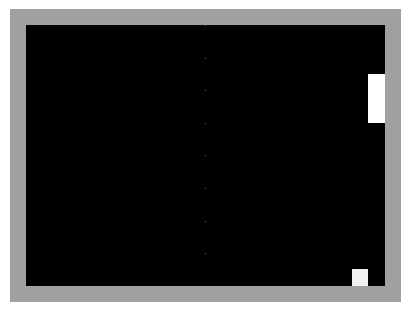

```
Recompensa total: -1.2
```

```python
# ====== Ejemplo del código, rellena las partes que necesites. ======

env = gym.make("SimplePong-v0", render_mode="rgb_array",
               width=24, height=18, paddle_size=4, rgb_scale=18, max_steps=2000)

obs, _ = env.reset(seed=7)

fig, ax = plt.subplots(figsize=(5.5, 3.8))
frame = env.render()
im = ax.imshow(frame, interpolation="nearest")
ax.axis("off")
disp = display(fig, display_id=True)


# Inicializamos el acumulador de recompensa de la partida
total_r = 0.0
terminated = False
truncated = False

# Ejecutamos la partida hasta que termine (fallo o truncado)
while not (terminated or truncated):

    # Elegimos una acción aleatoria en cada paso
    action = env.action_space.sample()

    # Avanzamos un paso en el entorno con esa acción
    obs, reward, terminated, truncated, info = env.step(action)
    total_r += reward  # acumulamos la recompensa

    # Actualizamos la imagen del entorno en la misma figura
    frame = env.render()
    im.set_data(frame)
    fig.canvas.draw_idle()
    disp.update(fig)
    time.sleep(0.01)

print("Recompensa total:", round(total_r, 2))
env.close()
plt.close(fig)
```

**Ejercicio 1.2.2 (0,25 pto):** Implementar un agente reactivo para `SimplePong-v0` que siga la pelota:

- Cargar el entorno (parámetros de la práctica) y fijar una semilla reproducible.
- Programar la política que siga la pala a la pelota como se muestra en el gif
- Ejecutar **1 episodio** mostrando la animación en una *única figura* que se actualice en tiempo real (mismo `display_id`) y, al finalizar, imprimir la **recompensa total**.

[figure not shown]

```
Recompensa total del agente reactivo: 29.0
```

```python
# ====== DEMO EN JUPYTER (una sola figura actualizada) ======
env = gym.make("SimplePong-v0", render_mode="rgb_array",
               width=24, height=18, paddle_size=4, rgb_scale=18, max_steps=2000)

obs, _ = env.reset(seed=7)

fig, ax = plt.subplots(figsize=(5.5, 3.8))
frame = env.render()
im = ax.imshow(frame, interpolation="nearest")
ax.axis("off")
disp = display(fig, display_id=True)

# Recompensa total del episodio
total_r = 0.0
terminated = False
truncated = False

# Bucle del episodio: la pala sigue la posición vertical de la pelota
while not (terminated or truncated):

    # Obs = [paddle_y_norm, ball_x_norm, ball_y_norm, vx_norm, vy_norm]
    paddle_y_norm = obs[0]
    ball_y_norm   = obs[2]

    # Política reactiva: la pala se mueve hacia la pelota
    tol = 0.01  # pequeña tolerancia para no oscilar
    if ball_y_norm > paddle_y_norm + tol:
        action = 2  # mover pala hacia abajo
    elif ball_y_norm < paddle_y_norm - tol:
        action = 0  # mover pala hacia arriba
    else:
        action = 1  # mantener posición

    # Aplicamos la acción al entorno
    obs, reward, terminated, truncated, info = env.step(action)
    total_r += reward

    # Actualizamos la imagen en la misma figura
    frame = env.render()
    im.set_data(frame)
    fig.canvas.draw_idle()
    disp.update(fig)
    time.sleep(0.001)  # ~50 FPS

print("Recompensa total del agente reactivo:", round(total_r, 2))

env.close()
plt.close(fig)
```

El resultado esperado es el siguiente:

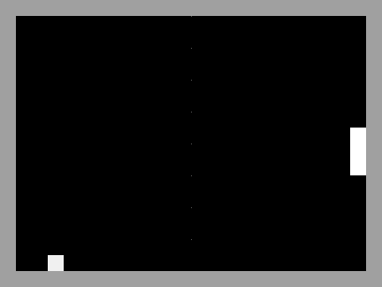

**Fuentes Ejercicio 1:**  
M2 – Gymnasium  
M3 – Procesos de Decisión de Markov (MDP)

## 2 Agente DQN jugador del Pong(2 ptos)

En este apartado implementaremos una DQN teniendo en cuenta la exploración-explotación (epsilon-*greedy*), la red objetivo, y el buffer de repetición de experiencias.

Definiremos el buffer como sigue:

```python
class experienceReplayBuffer:

    def __init__(self, memory_size=50000, burn_in=10000):
        self.memory_size = memory_size
        self.burn_in = burn_in
        self.buffer = namedtuple('Buffer',
            field_names=['state', 'action', 'reward', 'done', 'next_state'])
        self.replay_memory = deque(maxlen=memory_size)

    def sample_batch(self, batch_size=32):
        samples = np.random.choice(len(self.replay_memory), batch_size,
                                   replace=False)
        # Use asterisk operator to unpack deque
        batch = zip(*[self.replay_memory[i] for i in samples])
        return batch

    def append(self, state, action, reward, done, next_state):
        self.replay_memory.append(
            self.buffer(state, action, reward, done, next_state))

    def burn_in_capacity(self):
        return len(self.replay_memory) / self.burn_in
```

### 2.1 Implementación de la Clase PongNeural

Primeramente implementaremos la red neuronal, utilizando un modelo Secuencial con la siguiente configuración:

- Tres capas completamente conectadas (representadas en pytorch por nn.Lineal) con 128 y 64 neuronas cada una, bias=True, y activación ReLU
- Una capa de salida completamente conectada y bias=True

Usaremos el optimizador Adam para entrenar la red.

**Ejercicio 2.1 (0.25 ptos):** Implementar la clase `PongNeural:()`. Inicializar las variables necesarias y definir el modelo Secuencial de red neuronal indicado.

**Nota**: se os proporciona el código pre-implementado. La implementación que se pide en el enunciado está indicada en los bloques *TODO* y/o con variables igualadas a *None*.

```python
class PongNeural(torch.nn.Module):

    ###################################
    ###inicializacion y modelo###
    def __init__(self, env, learning_rate=1e-3, optimizer = None, device=None):
        """
        Params
        ======
        n_inputs: tamano del espacio de estados
        n_outputs: tamano del espacio de acciones
        actions: array de acciones posibles
        """
        ######################################
        super(PongNeural, self).__init__()

        # numero de entradas del estado
        self.n_inputs = env.observation_space.shape[0]

        # numero de acciones posibles
        self.n_outputs = env.action_space.n

        # lista con las acciones validas
        self.actions = np.arange(self.n_outputs)

        # guardamos lr
        self.learning_rate = learning_rate


        # definir el dispositivo cpu o gpu
        self.device = device if device else torch.device('cuda' if torch.cuda.is_available() else 'cpu')



        #######################################
        ##construccion de la red neuronal
        # arquitectura secuencial con 3 capas ocultas y relu
        self.model = torch.nn.Sequential(
            torch.nn.Linear(self.n_inputs, 128, bias=True),
            torch.nn.ReLU(),
            torch.nn.Linear(128, 64, bias=True),
            torch.nn.ReLU(),
            torch.nn.Linear(64, 64, bias=True),
            torch.nn.ReLU(),
            torch.nn.Linear(64, self.n_outputs, bias=True)
        ).to(self.device)


        #######################################
        ##inicializar el optimizador
        if optimizer is None:
            self.optimizer = torch.optim.Adam(self.parameters(), lr=self.learning_rate)
        else:
            self.optimizer = optimizer



    ### metodo e greedy
    # politica epsilon greedy
    # con prob epsilon elegimos accion aleatoria
    # si no elegimos la accion con mayor valor q
    def get_action(self, state, epsilon=0.05):

        if np.random.random() < epsilon:
            action = np.random.choice(self.actions)   # accion aleatoria
        else:
            qvals = self.get_qvals(state)             # obtenemos valores q
            action = torch.max(qvals, dim=-1)[1].item() # mejor accion segun q
        return action


    def get_qvals(self, state):
        if type(state) is tuple:
            state = np.array([np.ravel(s) for s in state])
        state_t = torch.FloatTensor(state).to(self.device)
        return self.model(state_t)
```

### 2.2 Implementación del Agente DQN con Exploración/Explotación y Sincronización de Redes

A continuación implementaremos una clase que defina el comportamiento del agente DQN teniendo en cuenta:

- La **exploración/explotación** (decaimiento de epsilon)
- La **actualización y sincronización** de la red principal y la red objetivo (pérdida)
- Consideraremos que el agente ha aprendido a realizar la tarea (i.e. el "juego" termina) cuando obtiene una **media de mínimo 18.5 durante 100 episodios consecutivos**.

**Ejercicio 2.2 (0.75 ptos):** Implementar los siguientes puntos de la clase `DQNAgent()`:

1. Declarar las variables de la clase
2. Inicializar las variables necesarias
3. Implementar la acción a tomar
4. Actualizar las variables de la red principal según la frecuencia establecida en los hiperparámetros
5. Calcular la pérdida (ecuación de Bellman, etc.)
6. Sincronizar la red objetivo según la frecuencia establecida en los hiperparámetros
7. Calcular la media de recompensas de los últimos 100 episodios
8. Comprobar límite de episodios
9. Actualizar epsilon según: $\max(\epsilon \cdot \epsilon_{\text{decay}}, 0.01)$

Además, durante el proceso se deben almacenar (*):

1. Las recompensas obtenidas en cada paso del entrenamiento
2. Las recompensas medias cada 100 episodios
3. La pérdida durante el entrenamiento
4. La evolución de epsilon a lo largo del entrenamiento
5. Almacena la cantidad de episodios necesarios para llevar acabo el entrenamiento en la variable episodes_train_dqn

**Nota**: se os proporciona el código pre-implementado. La implementación que se pide en el enunciado está indicada en los bloques *TODO* y/o con variables igualadas a *None*, salvo (*) donde tenéis que decidir en qué momento almacenar las variables que se indican.

```python
from tqdm.auto import tqdm

class DQNAgent:
    def __init__(self, env, main_network, buffer, epsilon=0.1, eps_decay=0.99, batch_size=32, min_episodes= 300, device = None):
        ######################################
        ##TODO: Declarar variables
        self.env = env                               # guardamos el entorno
        self.main_network = main_network             # red principal
        self.target_network = deepcopy(main_network) # red objetivo copia de la principal
        self.buffer = buffer                         # buffer de experiencia
        self.epsilon = epsilon                       # epsilon inicial
        self.eps_decay = eps_decay                   # factor de decaimiento de epsilon
        self.batch_size = batch_size                 # tamano de batch para updates
        self.nblock = 100                            # numero de episodios para media de recompensa
        self.initialize()                            # inicializamos contadores y listas
        self.min_episodes = min_episodes             # episodios minimos antes de parar por umbral
        self.device = device if device else torch.device('cuda' if torch.cuda.is_available() else 'cpu')  # Configurar el dispositivo (CPU o GPU)

        self.main_network.to(self.device)
        self.target_network.to(self.device)
        self.target_network.load_state_dict(self.main_network.state_dict())
        self.main_network.train()
        self.target_network.eval()
        self.huber = torch.nn.SmoothL1Loss()

    def initialize(self):
        ######################################
        ##TODO: Inicializa lo necesario
        self.step_count = 0                  # contador de steps totales
        self.training_rewards = []           # recompensas totales por episodio
        self.mean_training_rewards = []      # medias de recompensa por bloque de episodios
        self.loss_values = []               # perdidas medias por episodio
        self.epsilon_evolution = []         # evolucion de epsilon por episodio
        self.sync_eps = []                  # episodios donde se sincroniza la red objetivo
        self.update_loss = []               # perdidas de cada update dentro del episodio
        self.episodes_train_dqn = 0         # episodios usados para entrenar dqn
        # iniciamos el entorno para que el primer take_step tenga estado valido
        self.state0 = self.env.reset()[0]   # primer estado del entorno
        self.total_reward = 0.0             # reward acumulada del episodio actual
    ## Tomar nueva acción
    def take_step(self, eps, mode='train'):
        if mode == 'explore':
            # acción aleatoria en el burn-in y en la fase de exploración (epsilon)>
            action = self.env.action_space.sample()   # en modo explore usamos accion aleatoria
        else:
            # acción a partir del valor de Q (elección de la acción con mejor Q)
            action = self.main_network.get_action(self.state0, epsilon=eps)  # en modo train usamos politica epsilon greedy
            self.step_count += 1

        #TODO: tomar 'step' i obtener nuevo estado y recompensa. Guardar la experiencia en el buffer
        next_state, reward, terminated, truncated, info = self.env.step(action)  # damos un paso en el entorno
        done = terminated or truncated                                           # episodio termina si terminated o truncated
        self.total_reward += reward                                              # acumulamos recompensa del episodio
        self.buffer.append(self.state0, action, reward, done, next_state)       # guardamos experiencia en el buffer
        self.state0 = next_state                                                # actualizamos estado actual

        #TODO: resetear entorno 'if done'
        if done and mode == 'explore':                                          # en burn in reiniciamos el entorno al terminar
            self.state0 = self.env.reset()[0]
            self.total_reward = 0.0

        return done

    ## Entrenamiento
    def train(self, gamma=0.99, max_episodes=3000,
              batch_size=32,
              dnn_update_frequency=4,
              dnn_sync_frequency=2000, REWARD_THRESHOLD = 25):

        self.gamma = gamma

        # Rellenamos el buffer con N experiencias aleatorias ()
        print("Filling replay buffer (external burn-in)...")
        target = buffer.burn_in
        get_size = lambda: len(buffer.replay_memory)

        pbar = tqdm(total=target, desc="Replay burn-in", unit="exp")
        pbar.update(min(get_size(), target))

        while get_size() < target:
            before = get_size()
            agentDQN.take_step(agentDQN.epsilon, mode='explore')
            pbar.update(get_size() - before)

        pbar.close()
        print("Replay buffer lleno")



        episode = 0
        training = True
        print("Training...")
        while training:
            self.state0 = self.env.reset()[0]
            self.total_reward = 0
            gamedone = False
            while gamedone == False:
                # El agente toma una acción
                gamedone = self.take_step(self.epsilon, mode='train')
                ##################################################################################
                #####TODO:  Actualizar la red principal según la frecuencia establecida #######
                if self.step_count % dnn_update_frequency == 0 and len(self.buffer.replay_memory) >= self.batch_size:
                    self.update()                       # actualizamos la red principal cada cierto numero de steps



                ########################################################################################
                ###TODO: Sincronizar red principal y red objetivo según la frecuencia establecida#####
                if self.step_count % dnn_sync_frequency == 0:
                    self.target_network.load_state_dict(self.main_network.state_dict())  # copiamos pesos a la red objetivo
                    self.sync_eps.append(episode)                                       # guardamos episodio de sincronizacion



                if gamedone:
                    episode += 1
                    #######################################################################################
                    ###TODO: calcular la media de recompensa de los últimos X episodios, y almacenar#####
                    self.training_rewards.append(self.total_reward)                 # guardamos recompensa total del episodio
                    if len(self.training_rewards) >= self.nblock:
                        mean_rewards = np.mean(self.training_rewards[-self.nblock:])   # media en los ultimos nblock episodios
                    else:
                        mean_rewards = np.mean(self.training_rewards)                 # media con los episodios que haya

                    self.mean_training_rewards.append(mean_rewards)                   # guardamos media de recompensas
                    self.epsilon_evolution.append(self.epsilon)                       # guardamos epsilon actual
                    if len(self.update_loss) > 0:
                        self.loss_values.append(np.mean(self.update_loss))            # guardamos perdida media del episodio
                    else:
                        self.loss_values.append(0.0)
                    self.update_loss = []                                             # reiniciamos lista de perdidas del episodio
                    self.episodes_train_dqn = episode                                 # guardamos numero de episodios usados



                    #######################################################################################
                    ### TODO: Comprobar que todavía quedan episodios. Parar el aprendizaje si se llega al límite


                    print("\rEpisode {:d} Mean Rewards {:.2f} Epsilon {}\t\t".format(
                        episode, mean_rewards, self.epsilon), end="")

                    # Comprobamos que todavía quedan episodios
                    if episode >= max_episodes:
                        training = False
                        print('\nEpisode limit reached.')
                        print('\nEnvironment solved in {} episodes!'.format(
                            episode))
                        break

                    #######################################################################################
                    ### TODO: Añadir min episodes
                    if mean_rewards >= REWARD_THRESHOLD and self.min_episodes < episode :
                        training = False
                        print('\nEpisode limit reached.')
                        print('\nEnvironment solved in {} episodes!'.format(
                            episode))
                        break


                    #################################################################################
                    ######TODO: Actualizar epsilon según la velocidad de decaimiento fijada#######
                    self.epsilon = max(self.epsilon * self.eps_decay, 0.01)   # actualizamos epsilon con decaimiento y minimo 0.01

    ## Cálculo de la pérdida
    def calculate_loss(self, batch):
        # Separamos las variables de la experiencia y las convertimos a tensores
        states, actions, rewards, dones, next_states = [i for i in batch]
        rewards_vals = torch.FloatTensor(rewards).to(self.device)
        actions_vals = torch.LongTensor(np.array(actions)).reshape(-1,1).to(self.device)
        dones_t = torch.tensor(dones, dtype=torch.bool).to(self.device)

        # Obtenemos los valores de Q de la red principal
        qvals = torch.gather(self.main_network.get_qvals(states), 1, actions_vals).to(self.device)
        # Obtenemos los valores de Q objetivo. El parámetro detach() evita que estos valores actualicen la red objetivo
        qvals_next = torch.max(self.target_network.get_qvals(next_states),
                               dim=-1)[0].detach().to(self.device)
        qvals_next[dones_t.bool()] = 0

        #################################################################################
        ### TODO: Calcular ecuación de Bellman
        expected_qvals = rewards_vals + self.gamma * qvals_next      # calculamos el valor objetivo usando la ecuacion de bellman

        #################################################################################
        ### TODO: Calcular la pérdida (MSE) o SmoothL1Loss (recomendad)
        loss = self.huber(qvals, expected_qvals.unsqueeze(1))        # calculamos la perdida con smooth l1
        return loss



    def soft_update(self, tau=0.005):
        """Actualiza suavemente la red objetivo con Polyak averaging."""
        with torch.no_grad():
            for param_t, param in zip(self.target_network.parameters(), self.main_network.parameters()):
                param_t.data.mul_(1.0 - tau).add_(param.data, alpha=tau)


    def update(self):
        self.main_network.optimizer.zero_grad()# eliminamos cualquier gradiente pasado
        batch = self.buffer.sample_batch(batch_size=self.batch_size)# seleccionamos un conjunto del buffer
        loss = self.calculate_loss(batch)# calculamos la pérdida
        loss.backward()# hacemos la diferencia para obtener los gradientes
        torch.nn.utils.clip_grad_norm_(self.main_network.parameters(), 10.0)
        self.main_network.optimizer.step()#aplicamos los gradientes a la red neuronal

        self.soft_update()
        self.update_loss.append(loss.item())
```

### 2.3 Entrenamiento del Modelo

A continuación entrenaremos el modelo con los siguientes hiperparámetros:

- Velocidad de aprendizaje: 1e-4
- Tamaño del batch: 64
- Número de episodios: 4000
- Número de episodios para rellenar el buffer (burn-in): 5000
- Frecuencia de actualización de la red neuronal: cada 3 pasos
- Frecuencia de sincronización con la red objetivo: cada 1000 pasos
- Capacidad máxima del buffer: 100000
- Factor de descuento (gamma): 0.99
- Epsilon: 1, con decaimiento de 0.997
- Umbral de recompensa objetivo: 18.5

**Ejercicio 2.3 (Sin puntuación):** Cargar el modelo de red neuronal y entrenar el agente con los hiperparámetros que see acaban de definir. Comentar los resultados del entrenamiento.

```python
#definición de las variables
# hiperparametros del agente dqn
learning_rate = 1e-4          # lr de la red
batch_size = 64               # tamano del batch
max_episodes = 4000           # numero maximo de episodios
burn_in = 5000                # experiencias para rellenar el buffer al inicio
memory_size = 100000          # capacidad maxima del buffer
gamma = 0.99                  # factor de descuento
epsilon_inicial = 1.0         # epsilon inicial para exploracion
eps_decay = 0.997             # factor de decaimiento de epsilon
dnn_update_frequency = 3      # actualizamos la red cada 3 pasos
dnn_sync_frequency = 1000     # sincronizamos la red objetivo cada 1000 pasos
REWARD_THRESHOLD = 18.5       # umbral de recompensa objetivo
min_episodes = 300            # episodios minimos antes de parar por umbral

# creacion del entorno pong
env = gym.make(
    "SimplePong-v0",
    render_mode="rgb_array",
    width=24,
    height=18,
    paddle_size=4,
    rgb_scale=18,
    max_steps=2000
)

# creacion del buffer de repeticion de experiencias
buffer = experienceReplayBuffer(
    memory_size=memory_size,
    burn_in=burn_in
)

# creacion de la red neuronal principal
main_network = PongNeural(
    env=env,
    learning_rate=learning_rate
)

# creacion del agente dqn
agentDQN = DQNAgent(
    env=env,
    main_network=main_network,
    buffer=buffer,
    epsilon=epsilon_inicial,
    eps_decay=eps_decay,
    batch_size=batch_size,
    min_episodes=min_episodes
)
```

```python
# TODO: Entrenamiento
# Tiempo estimado de entrenamiento en Google Colab: ~30 minutos.
# Si al finalizar todos los episodios el agente aún no logra superar el entorno,
# vuelve a ejecutar el entrenamiento.
# Habitualmente, alrededor de los 2000-3000 episodios el agente consigue vencer el entorno
# con un tiempo de ejecución inferior a 30 minutos en Google Colab.


agentDQN.train(
    gamma=gamma,
    max_episodes=max_episodes,
    batch_size=batch_size,
    dnn_update_frequency=dnn_update_frequency,
    dnn_sync_frequency=dnn_sync_frequency,
    REWARD_THRESHOLD=REWARD_THRESHOLD
)
```

```
Filling replay buffer (external burn-in)...
```

```
Replay buffer lleno
Training...
Episode 1058 Mean Rewards 18.57 Epsilon 0.041762100620586655
Episode limit reached.

Environment solved in 1058 episodes!
```

**Comentarios:**  
Al principio me dio problemas el burn in porque el entorno no estaba reseteado antes de empezar y me saltaba el error de que no se podia hacer step sin hacer reset primero asi que tuve que inicializar el estado en el metodo initialize para que el primer take step tuviera un estado valido y ya no me ha vuelto a fallar  
Sobre el entrenamiento el agente ha llegado al umbral de reward bastante antes de lo que esperaba mas o menos por el episodio mil algo que esta por debajo de lo que pone en el enunciado pero tampoco me sorprende porque este entorno tiene mucha aleatoriedad y depende un monton de la semilla la inicializacion de pesos y demás.  
También se ve que el epsilon baja bastante rapido y a partir de ahí el comportamiento se vuelve mas estable y sube la media de reward hasta pasar el 18,5 que era el objetivo  
En general, creo que el entrenamiento ha ido bien y el modelo ha conseguido aprender una estrategia aceptable para este pong simplificado

### 2.4 Análisis del entrenamiento

**Ejercicio 2.4 (0.25 ptos):** Representar:

1. Gráfico con las recompensas obtenidas a lo largo del entrenamieno, la evolución de las recompensas medias cada 100 episodios, y el umbral de recompensa establecido por el entorno.
2. Gráfico con la evolución de la perdida a lo largo del entrenamiento
3. Gráfico con la evolución de epsilon a lo largo del entrenamiento

Comentar los resultados obtenidos.

```python
def plot_rewards(tr_rewards, mean_tr_rewards, th):
  #TODO
  # grafico de recompensas por episodio y media movil mas umbral
  plt.figure(figsize=(10,5))
  plt.plot(tr_rewards, label='reward episodio', alpha=0.4)
  plt.plot(mean_tr_rewards, label='media reward ultimos 100 episodios')
  plt.axhline(th, color='red', linestyle='--', label='umbral recompensa')
  plt.xlabel('episodio')
  plt.ylabel('recompensa')
  plt.title('evolucion de las recompensas durante el entrenamiento')
  plt.legend()
  plt.grid(True)
  plt.show()
```

```python
def plot_loss(tr_loss):
  #TODO
  # grafico de la perdida media por episodio
  plt.figure(figsize=(10,5))
  plt.plot(tr_loss)
  plt.xlabel('episodio')
  plt.ylabel('loss')
  plt.title('evolucion de la perdida durante el entrenamiento')
  plt.grid(True)
  plt.show()
```

```python
def plot_epsilon(eps_evolution):
  #TODO
  # grafico de la evolucion de epsilon
  plt.figure(figsize=(10,5))
  plt.plot(eps_evolution)
  plt.xlabel('episodio')
  plt.ylabel('epsilon')
  plt.title('evolucion de epsilon durante el entrenamiento')
  plt.grid(True)
  plt.show()
```

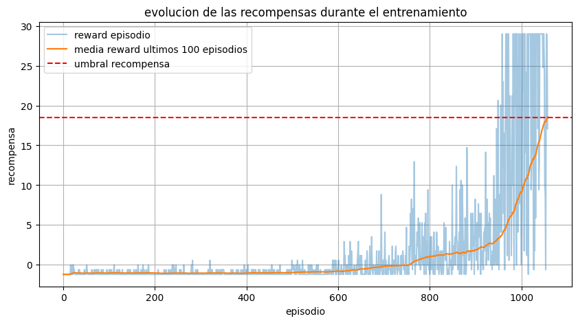

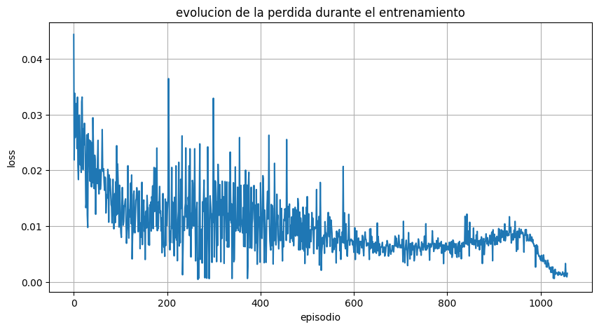

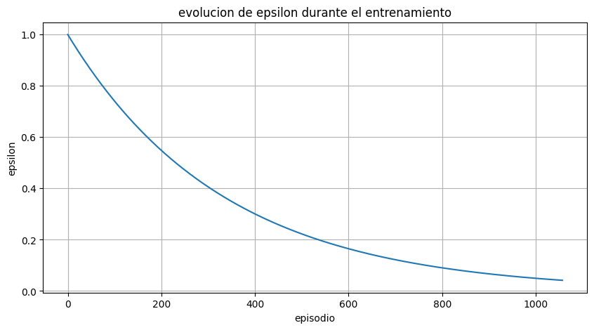

```python
#TODO mostrar gráficas

plot_rewards(agentDQN.training_rewards, agentDQN.mean_training_rewards, REWARD_THRESHOLD)
plot_loss(agentDQN.loss_values)
plot_epsilon(agentDQN.epsilon_evolution)
```

Una vez entrenado el agente, nos interesa comprobar cómo de bien ha aprendido y si es capaz de conseguir resolver el entorno. Para ello, recuperamos el modelo entrenado y dejamos que el agente tome acciones aleatorias según ese modelo y observamos su comportamiento.

### 2.5 Test del agente en Pong

**Ejercicio 2.5 (0.75 ptos):** Cargar el modelo entrenado y evaluar su comportamiento en el entorno `Pong-v0`.

Para ello, realiza las siguientes tareas en este orden:

1. **Visualización de una partida:** Ejecuta una partida completa del agente entrenado en el entorno Pong y muestra por pantalla el resultado final (por ejemplo, puntuación total o número de puntos ganados).
2. **Evaluación cuantitativa:** Ejecuta el agente durante **20 partidas consecutivas** sin renderizar y calcula las métricas de rendimiento:
- Recompensa media obtenida en las 20 partidas → almacénala en la variable `mean_reward_dqn_test`.
3. **Gráfico de resultados:** Representa un gráfico con la suma de recompensas obtenidas en las 20 partidas de test, incluyendo una línea horizontal que indique el umbral de recompensa objetivo (por ejemplo, `REWARD_THRESHOLD = 18`).
4. **Análisis final:** Comenta los resultados obtenidos:
   - ¿Ha alcanzado el agente un rendimiento estable y superior al umbral de recompensa?
   - ¿Muestra el comportamiento esperado en Pong?
   - ¿Qué cambios podrías aplicar al entrenamiento (por ejemplo, tasa de aprendizaje, frecuencia de sincronización o epsilon decay) para mejorar su desempeño?

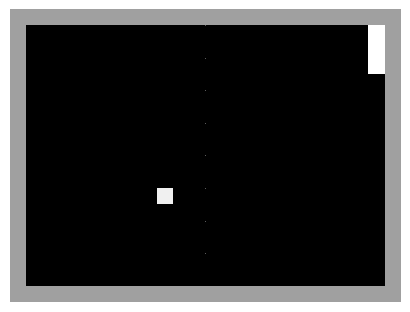

```
recompensa total partida test dqn: 29.0
```

```python
#TODO: Visualización de una partida

# visualizacion de una partida con el agente dqn entrenado
env_test = gym.make(
    "SimplePong-v0",
    render_mode="rgb_array",
    width=24,
    height=18,
    paddle_size=4,
    rgb_scale=18,
    max_steps=2000
)

state, _ = env_test.reset(seed=123)   # estado inicial reproducible
total_reward = 0.0                    # acumulamos recompensa

fig, ax = plt.subplots(figsize=(5.5, 3.8))
frame = env_test.render()
im = ax.imshow(frame, interpolation="nearest")
ax.axis("off")
disp = display(fig, display_id=True)

done = False
while not done:
    # usamos la politica aprendida sin exploracion epsilon 0
    action = agentDQN.main_network.get_action(state, epsilon=0.0)

    next_state, reward, terminated, truncated, info = env_test.step(action)
    total_reward += reward
    state = next_state
    done = terminated or truncated

    # actualizamos el frame en la misma figura
    frame = env_test.render()
    im.set_data(frame)
    fig.canvas.draw_idle()
    disp.update(fig)
    time.sleep(0.01)

print("recompensa total partida test dqn:", round(total_reward, 2))
env_test.close()
plt.close(fig)
```

```
recompensa media test dqn en 20 episodios: 29.0
```

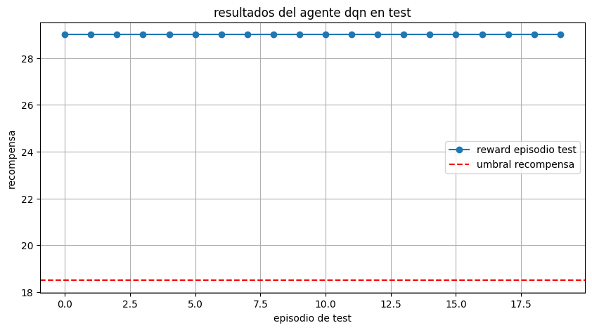

```python
#TODO: Evaluación y gráfico de los resultados

# evaluacion cuantitativa del agente dqn en 20 partidas
env_test = gym.make(
    "SimplePong-v0",
    render_mode=None,
    width=24,
    height=18,
    paddle_size=4,
    rgb_scale=18,
    max_steps=2000
)

n_episodios_test = 20
rewards_test = []   # guardamos la recompensa total de cada partida

for ep in range(n_episodios_test):
    state, _ = env_test.reset(seed=ep)   # cambiamos semilla para variar trayectorias
    total_r = 0.0
    done = False

    while not done:
        # usamos politica greedy sin exploracion
        action = agentDQN.main_network.get_action(state, epsilon=0.0)
        state, reward, terminated, truncated, info = env_test.step(action)
        total_r += reward
        done = terminated or truncated

    rewards_test.append(total_r)

# recompensa media en las 20 partidas de test
mean_reward_dqn_test = float(np.mean(rewards_test))
print("recompensa media test dqn en 20 episodios:", round(mean_reward_dqn_test, 2))

# grafico de resultados de test
plt.figure(figsize=(10,5))
plt.plot(rewards_test, marker='o', label='reward episodio test')
plt.axhline(REWARD_THRESHOLD, color='red', linestyle='--', label='umbral recompensa')
plt.xlabel('episodio de test')
plt.ylabel('recompensa')
plt.title('resultados del agente dqn en test')
plt.grid(True)
plt.legend()
plt.show()

env_test.close()
```

**Comentarios:**  
En el test se ve que el agente juega bastante bien y mantiene la pelota durante muchos rebotes sin perderla enseguida en la partida renderizada ya se nota que la pala se mueve con sentido y no de forma aleatoria y que intenta colocarse justo donde va a llegar la pelota.  
En las 20 partidas de test el resultado es muy consistente todas las partidas estan sobre 29 de recompensa que es bastante por encima del umbral 18 5 que marcaba el ejercicio esto me llama bastante la atencion porque en la fase de entrenamiento habia bastante variación, pero en test el comportamiento es mucho mas estable entiendo que se debe a que en test ya no hay exploración y la política es totalmente greedy  
Lo mas destacable es precisamente esa estabilidad que consigue despues de entrenar solo mil episodios, mas o menos, lo que indica que la red ha captado la dinamica del juego de forma bastante solida tampoco parece que haya overfitting porque se comporta igual con distintas semillas.  
Si quisiera mejorar aun mas el rendimiento podria probar con un decay de epsilon un pelin mas lento para explorar mas al principio o ajustar la frecuencia de sincronización de la red objetivo tambien podria bajar un poco el learning rate para ver si la política final queda aun mas fina pero en general el comportamiento ya es bastante bueno para este entorno tan simple.

**Fuentes Ejercicio 2:**  
M8 – Soluciones Aproximadas  
M9 – Deep Q-Networks  
M6 – Métodos de Diferencia Temporal  
Reinforcement Learning (DQN) Tutorial - https://docs.pytorch.org/tutorials/intermediate/reinforcement_q_learning.html  
Implementing Deep-Q-Learning using PyTorch - https://medium.com/%40JDVariadic/implementing-deep-q-learning-using-pytorch-23e3715531ee  
Vanilla DQN, Double DQN, and Dueling DQN implemented in PyTorch - https://github.com/dxyang/DQN_pytorch

## 3 Agente Dueling DQN (2 ptos)

En este apartado resolveremos el mismo entorno con las mismas características para el agente, pero usando una dueling DQN. Como en el caso anterior, primero definiremos el modelo de red neuronal, luego describiremos el comportamiento del agente, lo entrenaremos y, finalmente, testearemos el funcionamiento del agente entrenado.

### 3.1 Definición de la arquitectura de la red neuronal

El objetivo principal de las dueling DQN es "ahorrarse" el cálculo del valor de Q en aquéllos estados en los que es irrelevante la acción que se tome. Para ello se descompone la función Q en dos componentes:

$$Q(s, a) = A(s, a) + V (s)$$

Esta descomposición se realiza a nivel de la arquitectura de la red neuronal. Las primeras capas que teníamos en la DQN serán comunes, y luego la red se dividirá en dos partes separadas definidas por el resto de capas.

La descomposición en sub-redes del modelo de la DQN implementada en el apartado anterior, será entonces:

1. Bloque común:
- Una primera capa completamente conectada de 128 neuronas y `bias = True`, con activación ReLU
2. Para cada una de las subredes de ventaja A(s,a) y valor V(s):
- Una capa completamente conectada de 64 neuronas y `bias = True`, con activación ReLU
- Una última capa completamente conectada y `bias = True`. Esta será nuestra capa de salida y por tanto el número de neuronas de salida dependerá de si se trata de la red A(s,a), que tendrá tantas neuronas como dimensiones tenga el espacio de acciones, o si se trata de la red V(s), con un valor por estado.

**Ejercicio 3.1 (0.25 ptos):** Implementar la clase `duelingDQN()`. Inicializar las variables necesarias y definir el modelo de red neuronal indicado.

**Nota**: se os proporciona el código pre-implementado. La implementación que se pide en el enunciado está indicada en los bloques *TODO* y/o con variables igualadas a *None*.

```python
import torch.autograd as autograd

class duelingDQN(torch.nn.Module):

    def __init__(self, env, device=None, learning_rate=1e-3):

        """
        Parámetros
        ==========
        n_inputs: tamaño del espacio de estados
        n_outputs: tamaño del espacio de acciones
        actions: array de acciones posibles
        """

        ###################################
        ####TODO: Inicializar variables####
        super(duelingDQN, self).__init__()
        self.device = device if device else torch.device('cuda' if torch.cuda.is_available() else 'cpu')

        # numero de entradas del estado
        self.n_inputs = env.observation_space.shape[0]

        # numero de acciones posibles
        self.n_outputs = env.action_space.n

        # lista con las acciones validas
        self.actions = np.arange(self.n_outputs)

        ######


        #######################################
        ##TODO: Construcción de la red neuronal
        # Red común
        ##Construcción de la red neuronal

        # bloque comun lineal 128 con relu
        self.model_common = torch.nn.Sequential(
            torch.nn.Linear(self.n_inputs, 128, bias=True),
            torch.nn.ReLU()
        ).to(self.device)

        # Subred de la función de Valor
        self.fc_layer_inputs = self.feature_size()

        # subred de ventaja a s a
        self.advantage  = torch.nn.Sequential(
            torch.nn.Linear(self.fc_layer_inputs, 64, bias=True),
            torch.nn.ReLU(),
            torch.nn.Linear(64, self.n_outputs, bias=True)
        ).to(self.device)

        # Subred de la Ventaja A(s,a)
        # subred de valor v s
        self.value = torch.nn.Sequential(
            torch.nn.Linear(self.fc_layer_inputs, 64, bias=True),
            torch.nn.ReLU(),
            torch.nn.Linear(64, 1, bias=True)
        ).to(self.device)

        #######
        #######################################
        ##TODO: Inicializar el optimizador
        # usamos adam igual que en dqn normal
        self.optimizer = torch.optim.Adam(self.parameters(), lr=learning_rate)




    #######################################
    #####TODO: función forward#############
    def forward(self, state):

        # Conexión entre capas de la red común
        common_out = self.model_common(state)          # pasamos estado por bloque comun

        # Conexión entre capas de la Subred de Valor
        advantage = self.advantage(common_out)         # calculamos ventaja a s a

        # Conexión entre capas de la Subred de Ventaja
        value = self.value(common_out)                 # calculamos valor v s


        ## Agregar las dos subredes:
        # Q(s,a) = V(s) + (A(s,a) - 1/|A| * sum A(s,a'))
        adv_mean = advantage.mean(dim=1, keepdim=True) # media de ventajas por accion
        action = value + (advantage - adv_mean)        # combinamos valor mas ventaja centrada

        return action




        #return action


    #######



    ### Método e-greedy
    def get_action(self, state, epsilon=0.05):
        if np.random.random() < epsilon:
            action = np.random.choice(self.actions)
        else:
            qvals = self.get_qvals(state)
            action = torch.max(qvals, dim=-1)[1].item()
        return action



    def get_qvals(self, state):
        # state: np.array o list/tuple
        state = np.array(state, dtype=np.float32)
        if state.ndim == 1:
            state = state[None, :]
        state_t = torch.from_numpy(state).to(self.device)
        return self.forward(state_t)



    def feature_size(self):
        dummy_input = torch.zeros(1, self.n_inputs).to(self.device)
        return self.model_common(dummy_input).view(1, -1).size(1)
```

Para el buffer de repetición de experiencias podemos usar exactamente la misma clase experienceReplayBuffer descrita en el apartado anterior de la DQN.

### 3.2 Definición del agente

La diferencia entre la DQN y la dueling DQN se centra, como hemos visto, en la definición de la arquitectura de la red. Pero el proceso de aprendizaje y actualización es exactamente el mismo. Así, podemos recuperar la clase implementada en el apartado anterior, DQNAgent() y reutilizarla aquí bajo el nombre de duelingDQNAgent(). Lo único que deberemos hacer es añadir el optimizador entre las variables a declarar y adaptar la función de pérdida al formato Functional de pytorch.

**Ejercicio 3.2 (0.75 pto):** Implementar la clase `duelingDQNAgent()` como la `DQNAgent()`

De nuevo, durante el proceso se deben almacenar (*):

- Las recompensas obtenidas en cada paso del entrenamiento
- Las recompensas medias de los 100 episodios anteriores
- La pérdida durante el entrenamiento
- La evolución de epsilon a lo largo del entrenamiento

**Nota**: se os proporciona el código pre-implementado. La implementación que se pide en el enunciado está indicada en los bloques *TODO* y/o con variables igualadas a *None*, salvo (*) en qué momento almacenar las variables que se indican.

```python
class duelingDQNAgent:

    def __init__(self, env, main_network, buffer, reward_threshold, epsilon=0.1, eps_decay=0.99, batch_size=32, device= None):
        """"
        Params
        ======
        env: entorno
        target_network: clase con la red neuronal diseñada
        target_network: red objetivo
        buffer: clase con el buffer de repetición de experiencias
        epsilon: epsilon
        eps_decay: epsilon decay
        batch_size: batch size
        nblock: bloque de los X últimos episodios de los que se calculará la media de recompensa
        reward_threshold: umbral de recompensa definido en el entorno
        """
        self.device = torch.device(device if device else ('cuda' if torch.cuda.is_available() else 'cpu'))

        ###############################################################
        #####TODO 1: inicialitzar variables######

        # guardamos entorno y redes
        self.env = env                               # entorno pong
        self.main_network = main_network             # red principal dueling
        self.target_network = deepcopy(main_network) # red objetivo copia de la principal
        self.buffer = buffer                         # buffer de repeticion de experiencias
        self.epsilon = epsilon                       # epsilon inicial
        self.eps_decay = eps_decay                   # factor de decaimiento de epsilon
        self.batch_size = batch_size                 # tamano del batch para updates
        self.nblock = 100                            # numero de episodios para media de recompensa
        self.reward_threshold = reward_threshold     # umbral de recompensa definido en el entorno

        # movemos redes a dispositivo y sincronizamos pesos
        self.main_network.to(self.device)
        self.target_network.to(self.device)
        self.target_network.load_state_dict(self.main_network.state_dict())
        self.main_network.train()
        self.target_network.eval()

        self.initialize()


    ###############################################################
    #####TODO 2: inicialitzar variables extra que se necessiten######
    def initialize(self):
        # inicializamos contadores y listas para metricas
        self.step_count = 0                   # contador de steps totales
        self.training_rewards = []            # recompensa total por episodio
        self.mean_training_rewards = []       # media de recompensas por bloque
        self.loss_values = []                 # perdida media por episodio
        self.epsilon_evolution = []           # evolucion de epsilon por episodio
        self.sync_eps = []                    # episodios donde se sincroniza la red objetivo
        self.update_loss = []                 # lista de losses dentro del episodio
        self.episodes_train_dueling = 0       # episodios usados para entrenar dueling dqn

        # estado inicial para el burn in
        self.state0 = self.env.reset()[0]     # primer estado del entorno
        self.total_reward = 0.0               # recompensa acumulada del episodio actual



    #################################################################################
    ######TODO 3:  Tomar nueva acción ###############################################
    def take_step(self, eps, mode='train'):
        if mode == 'explore':
            action = self.env.action_space.sample()  # accion aleatoria en el burn in
        else:
           action = self.main_network.get_action(self.state0, epsilon=eps)  # accion segun politica epsilon greedy
           self.step_count += 1

        #TODO: Realización de la acción y obtención del nuevo estado y la recompensa

        next_state, reward, terminated, truncated, info = self.env.step(action)
        done = terminated or truncated
        # actualizamos recompensa acumulada y guardamos experiencia en el buffer
        self.total_reward += reward
        self.buffer.append(self.state0, action, reward, done, next_state)
        self.state0 = next_state

        #TODO: resetear entorno 'if done'
        if done and mode == 'explore':
            self.state0 = self.env.reset()[0]
            self.total_reward = 0.0

        return done


    ## Entrenamiento
    def train(self, gamma=0.99, max_episodes=50000,
              batch_size=32,
              dnn_update_frequency=4,
              dnn_sync_frequency=2000, min_episodios=250):
        self.gamma = gamma
        # Rellenamos el buffer con N experiencias aleatorias ()
        print("Filling replay buffer (external burn-in)...")
        target = self.buffer.burn_in

        get_size = lambda: len(self.buffer.replay_memory)

        pbar = tqdm(total=target, desc="Replay burn-in", unit="exp")
        pbar.update(min(get_size(), target))

        while get_size() < target:
            before = get_size()
            self.take_step(self.epsilon, mode='explore')
            pbar.update(get_size() - before)

        pbar.close()
        print("Replay buffer lleno")





        episode = 0
        training = True
        print("Training...")
        while training:
            self.state0 = self.env.reset()[0]
            self.total_reward = 0
            gamedone = False
            while gamedone == False:
                # El agente toma una acción
                gamedone = self.take_step(self.epsilon, mode='train')

                #################################################################################
                #####TODO : Actualizar la red principal según la frecuencia establecida  #######
                if self.step_count % dnn_update_frequency == 0:
                    self.update()

                ########################################################################################
                ###TODO: Sincronizar red principal y red objetivo según la frecuencia establecida#####
                if self.step_count % dnn_sync_frequency == 0:
                    self.target_network.load_state_dict(
                        self.main_network.state_dict())
                    self.sync_eps.append(episode)

                if gamedone:
                    episode += 1
                    ##################################################################
                    ########TODO: Almacenar epsilon, training rewards i loss#######

                    # guardamos recompensa epsilon y perdida media del episodio
                    self.training_rewards.append(self.total_reward)
                    self.epsilon_evolution.append(self.epsilon)
                    mean_loss_ep = np.mean(self.update_loss) if self.update_loss else 0.0
                    self.loss_values.append(mean_loss_ep)
                    self.update_loss = []
                    self.episodes_train_dueling = episode

                    #######################################################################################
                    ###TODO : calcular la media de recompensa de los últimos X episodios, y almacenar#####
                    if len(self.training_rewards) >= self.nblock:
                        mean_rewards = np.mean(self.training_rewards[-self.nblock:])
                    else:
                        mean_rewards = np.mean(self.training_rewards)
                    self.mean_training_rewards.append(mean_rewards)
                    ###

                    print("\rEpisode {:d} Mean Rewards {:.2f} Epsilon {}\t\t".format(
                        episode, mean_rewards, self.epsilon), end="")

                    # Comprobar si se ha llegado al máximo de episodios
                    if episode >= max_episodes:
                        training = False
                        print('\nEpisode limit reached.')
                        break

                    # Termina el juego si la media de recompensas ha llegado al umbral fijado para este juego
                    # y se ha entrenado un mínimo de episodios
                    if mean_rewards >= self.reward_threshold and min_episodios <  episode:
                        training = False
                        print('\nEnvironment solved in {} episodes!'.format(
                            episode))
                        break

                    #################################################################################
                    ######TODO : Actualizar epsilon ########
                    self.epsilon = max(self.epsilon * self.eps_decay, 0.01)





     ## Cálculo de la pérdida
    def calculate_loss(self, batch):
        states, actions, rewards, dones, next_states = [i for i in batch]
        rewards_vals = torch.FloatTensor(rewards).to(self.device).reshape(-1,1)
        actions_vals = torch.LongTensor(np.array(actions)).reshape(-1,1).to(self.device)
        dones_t = torch.tensor(dones, dtype=torch.bool, device=self.device)


        # Obtenemos los valores de Q de la red principal
        qvals = torch.gather(self.main_network.get_qvals(states).to(self.device), 1, actions_vals)
        next_actions = torch.max(self.main_network.get_qvals(next_states).to(self.device), dim=-1)[1]
        next_actions_vals = next_actions.reshape(-1, 1).to(self.device)


        # Obtenemos los valores de Q de la red objetivo
        target_qvals = self.target_network.get_qvals(next_states).to(self.device)
        qvals_next = torch.gather(target_qvals, 1, next_actions_vals).detach()
        #####
        qvals_next[dones_t.squeeze()] = 0


        # Calculamos ecuación de Bellman
        expected_qvals = rewards_vals + self.gamma * qvals_next
        #Función Loss #####
        loss = F.smooth_l1_loss(qvals, expected_qvals)
        #######
        return loss


    def update(self):
        self.main_network.optimizer.zero_grad()  # eliminamos cualquier gradiente pasado
        batch = self.buffer.sample_batch(batch_size=self.batch_size) # seleccionamos un conjunto del buffer
        loss = self.calculate_loss(batch) # calculamos la pérdida
        loss.backward() # hacemos la diferencia para obtener los gradientes


        torch.nn.utils.clip_grad_norm_(self.main_network.parameters(), 10.0)


        self.main_network.optimizer.step() # aplicamos los gradientes a la red neuronal
        # Guardamos los valores de pérdida
        if self.device.type == 'cuda':
            self.update_loss.append(loss.detach().cpu().numpy())
        else:
            self.update_loss.append(loss.detach().numpy())
```

### 3.3 Entrenamiento del Modelo

A continuación entrenaremos el modelo dueling DQN con los mismos hiperparámetros con los que entrenamos la DQN.

**Ejercicio 3.3 (Sin puntuación):** Cargar el modelo de red neuronal y entrenar el agente con los mismos hiperparámetros usados para la DQN

```python
# hiperparametros para dueling dqn iguales que en dqn normal
learning_rate = 1e-4
batch_size = 64
max_episodes = 4000
burn_in = 5000
memory_size = 100000
gamma = 0.99
epsilon = 1.0
eps_decay = 0.997
REWARD_THRESHOLD_DUELING = 18.5  # mismo umbral que antes

# creamos entorno para el dueling dqn
env_dueling = gym.make(
    "SimplePong-v0",
    render_mode=None,
    width=24,
    height=18,
    paddle_size=4,
    rgb_scale=18,
    max_steps=2000
)

# creamos buffer de repeticion de experiencias
buffer_dueling = experienceReplayBuffer(
    memory_size=memory_size,
    burn_in=burn_in
)

# red neuronal dueling dqn
device = torch.device('cuda' if torch.cuda.is_available() else 'cpu')
dueling_net = duelingDQN(env_dueling, device=device, learning_rate=learning_rate)

# agente dueling dqn
agent_dueling = duelingDQNAgent(
    env=env_dueling,
    main_network=dueling_net,
    buffer=buffer_dueling,
    reward_threshold=REWARD_THRESHOLD_DUELING,
    epsilon=epsilon,
    eps_decay=eps_decay,
    batch_size=batch_size,
    device=device
)

# entrenamiento del agente dueling dqn
agent_dueling.train(
    gamma=gamma,
    max_episodes=max_episodes,
    batch_size=batch_size,
    dnn_update_frequency=3,    # misma frecuencia que en dqn
    dnn_sync_frequency=1000,   # misma frecuencia de sync
    min_episodios=300
)
```

```
Filling replay buffer (external burn-in)...
```

```
Replay buffer lleno
Training...
Episode 1344 Mean Rewards 18.60 Epsilon 0.017684696564496196
Environment solved in 1344 episodes!
```

**Comentarios:**  
En el enunciado decia que lo normal es que el modelo dueling no llegue a resolver el entorno pero en mi caso si lo ha conseguido aunque un poco mas tarde que el dqn normal mas o menos por el episodio 1300  
Entiendo que esto puede pasar porque el entorno es bastante sencillo y muy determinista y puede que la arquitectura dueling capture bien el valor global del estado y eso haga que converja al final aunque no sea lo mas habitual segun la práctica

### 3.4 Análisis del entrenamiento

**Ejercicio 3.4 (0.25 ptos):** Mostrar los mismos gráficos que con la DQN:

1. Recompensas obtenidas a lo largo del entrenamieno y la evolución de las recompensas medias cada 100 episodios, junto con el umbral de recompensa establecido por el entorno
2. Pérdida durante el entrenamiento
3. Evolución de epsilon a lo largo del entrenamiento

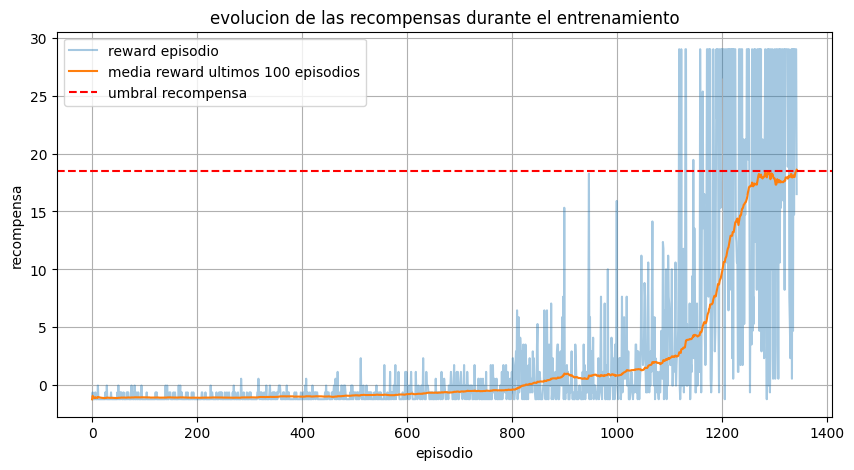

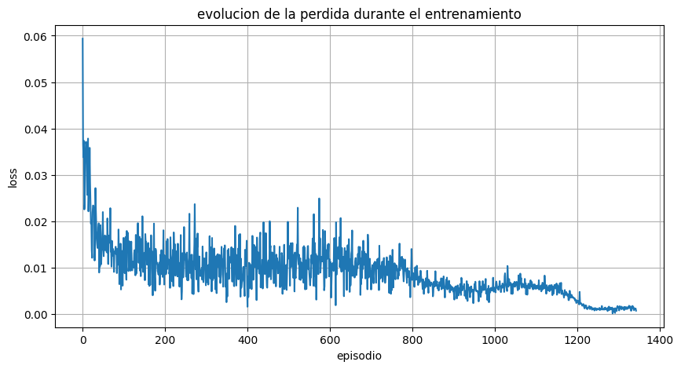

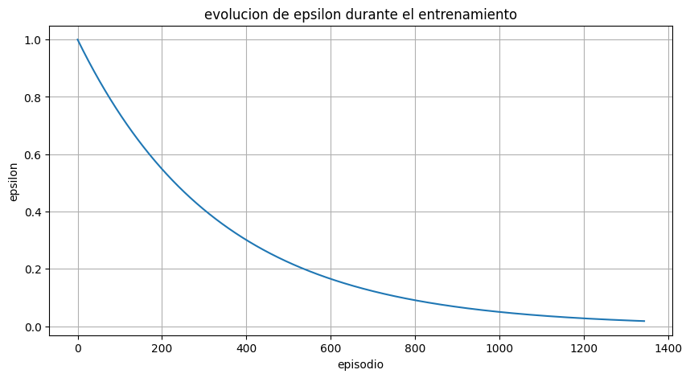

```python
#TODO mostrar gráficas

# graficas de entrenamiento para el agente dueling dqn
plot_rewards(
    agent_dueling.training_rewards,
    agent_dueling.mean_training_rewards,
    REWARD_THRESHOLD_DUELING
)

plot_loss(agent_dueling.loss_values)

plot_epsilon(agent_dueling.epsilon_evolution)
```

**Comentarios:**  
El entreno con dueling dqn me ha sorprendido porque en el enunciado avisaban de que probablemente no llegaría a resolver el entorno pero en mi caso si que lo ha hecho aunque ha necesitado bastantes mas episodios que la dqn normal. Si miro la gráfica de recompensas se ve que durante cientos de episodios el agente no aprende basicamente nada va rascando recompensas cercanas a cero y con mucha variabilidad. A partir mas o menos del episodio 1000 ya empieza a despegar igual que en la dqn pero mas tarde y con una subida bastante mas irregular.  
La media de los ultimos 100 episodios acaba cruzando el umbral de 18,5 aunque lo hace con menos estabilidad que la dqn. Por eso, creo que este modelo aunque funciona no es tan eficiente en este entorno pong porque la forma de separar valor y ventaja aqui no aporta gran cosa dado que es un entorno muy simple y las acciones casi siempre son relevantes para el estado.  
La perdida se ve bastante ruidosa tambien pero va bajando poco a poco y hacia el final del entrenamiento se estabiliza lo que indica que la red converge aunque de forma mas lenta. Epsilon también cae tal y como toca por el decay y cuando epsilon es muy bajo es cuando realmente el modelo empieza a comportarse de forma decente lo que tiene sentido porque ya explora menos.  
En resumen, el dueling dqn ha terminado funcionando aun que teoricamente no deberia ser el mejor modelo para un juego tan sencillo. supongo que con otra semilla o pequeñas variaciones podria no haber llegado a pasar el umbral y de hecho se nota que necesita mas pasos y es mas inestable que la dqn básica.

### 3.5 Test del agente en Pong

**Ejercicio 3.5 (0.75 ptos):** Cargar el modelo entrenado y evaluar su comportamiento en el entorno `Pong-v0`.

Para ello, realiza las siguientes tareas en este orden:

1. **Visualización de una partida:** Ejecuta una partida completa del agente entrenado en el entorno Pong y muestra por pantalla el resultado final (por ejemplo, puntuación total o número de puntos ganados).
2. **Evaluación cuantitativa:** Ejecuta el agente durante **20 partidas consecutivas** sin renderizar y calcula las métricas de rendimiento:
- Recompensa media obtenida en las 20 partidas → almacénala en la variable `mean_reward_dqn_test`.
3. **Gráfico de resultados:** Representa un gráfico con la suma de recompensas obtenidas en las 20 partidas de test, incluyendo una línea horizontal que indique el umbral de recompensa objetivo (por ejemplo, `REWARD_THRESHOLD = 18`).
4. **Análisis final:** Comenta los resultados obtenidos:
   - ¿Ha alcanzado el agente un rendimiento estable y superior al umbral de recompensa?
   - ¿Muestra el comportamiento esperado en Pong?
   - ¿El modelo mejora al anterior? Justifica la respuesta con base teórica.

[figure not shown]

```
recompensa total partida test dueling dqn: 29.0
```

```python
#TODO: Visualización de una partida

env_test_dueling = gym.make(
    "SimplePong-v0",
    render_mode="rgb_array",
    width=24,
    height=18,
    paddle_size=4,
    rgb_scale=18,
    max_steps=2000
)

state, _ = env_test_dueling.reset(seed=21)
total_r = 0.0
done = False

fig, ax = plt.subplots(figsize=(5.5, 3.8))
frame = env_test_dueling.render()
im = ax.imshow(frame, interpolation="nearest")
ax.axis("off")
disp = display(fig, display_id=True)

while not done:
    # usamos politica greedy sin exploracion epsilon 0
    action = dueling_net.get_action(state, epsilon=0.0)
    next_state, reward, terminated, truncated, info = env_test_dueling.step(action)
    total_r += reward
    state = next_state
    done = terminated or truncated

    # actualizamos el frame en la misma figura
    frame = env_test_dueling.render()
    im.set_data(frame)
    fig.canvas.draw_idle()
    disp.update(fig)
    time.sleep(0.01)

print("recompensa total partida test dueling dqn:", round(total_r, 2))
env_test_dueling.close()
plt.close(fig)
```

```
recompensa media test dueling dqn en 20 episodios: 28.999999999998824
```

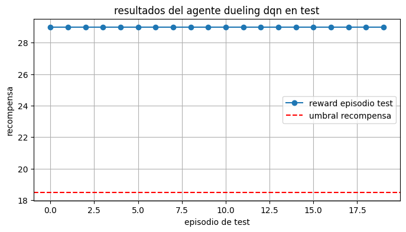

```python
#TODO: Evaluación y gráfico de los resultados

# evaluacion cuantitativa del agente dueling dqn en 20 episodios sin render
n_test_episodes = 20
test_rewards_dueling = []

env_eval_dueling = gym.make(
    "SimplePong-v0",
    render_mode=None,
    width=24,
    height=18,
    paddle_size=4,
    rgb_scale=18,
    max_steps=2000
)

for ep in range(n_test_episodes):
    # semilla distinta por episodio para variar un poco las trayectorias
    state, _ = env_eval_dueling.reset(seed=ep)
    done = False
    total_r = 0.0

    while not done:
        # politica greedy sobre la red dueling no usamos exploracion
        action = dueling_net.get_action(state, epsilon=0.0)
        next_state, reward, terminated, truncated, info = env_eval_dueling.step(action)
        total_r += reward
        state = next_state
        done = terminated or truncated

    test_rewards_dueling.append(total_r)

env_eval_dueling.close()

# recompensa media pedida en el enunciado
mean_reward_dueling_test = float(np.mean(test_rewards_dueling))
print("recompensa media test dueling dqn en", n_test_episodes, "episodios:", mean_reward_dueling_test)

# grafico de resultados en test
plt.figure(figsize=(8, 4))
plt.plot(test_rewards_dueling, marker="o", label="reward episodio test")
plt.axhline(REWARD_THRESHOLD_DUELING, color="r", linestyle="--", label="umbral recompensa")
plt.xlabel("episodio de test")
plt.ylabel("recompensa")
plt.title("resultados del agente dueling dqn en test")
plt.legend()
plt.grid(True)
plt.show()
```

**Comentarios:**  
En esta parte he reutilizado la red dueling ya entrenada para ver si de verdad habia aprendido algo y no solo durante el entreno. en la primera celda monto un entorno nuevo de test con render activo y voy haciendo pasos usando la politica greedy de la red es decir epsilon 0 para que siempre escoja la accion con mayor valor q. En cada paso actualizo el frame y acumulo la recompensa total hasta que el episodio termina. Al final se imprime la recompensa total de esa partida de ejemplo.  
En la segunda celda hago una evaluación mas seria sin render. Creo otro entorno y ejecuto 20 episodios seguidos siempre con epsilon 0 y guardo la recompensa de cada uno en una lista. luego calculo la media y la guardo en la variable mean_reward_dueling_test y dibujo un gráfico con las recompensas de los 20 episodios y una linea roja con el umbral 18,5 para comparar.  
Los resultados que salen son bastante buenos. En la partida con render la recompensa total es 29 o sea el agente mantiene la pelota bastante tiempo y la pala sigue el movimiento de forma muy segura. En los 20 episodios de test la recompensa media sale practicamente 29 y además la linea azul del gráfico es casi plana por encima del umbral rojo. Eso significa que el dueling dqn no solo ha llegado a aprender durante el entrenamiento sino que se comporta de forma muy estable en test y casi siempre consigue un rendimiento muy similar al agente dqn normal. En este entorno tan simple los dos modelos acaban funcionando casi igual de bien aunque el dueling haya tardado mas episodios en llegar a ese nivel.```

**Fuentes Ejercicio 3:**  
M9 – Deep Q-Networks  
M8 – Soluciones Aproximadas  
Understanding Dueling DQN: A Deep Dive into Reinforcement Learning - https://medium.com/%40sainijagjit/understanding-dueling-dqn-a-deep-dive-into-reinforcement-learning-575f6fe4328c  
Vanilla DQN, Double DQN, and Dueling DQN in PyTorch - https://github.com/dxyang/DQN_pytorch

## 4 Double DQN (2 ptos)

En este apartado implementaremos una doble DQN con la misma red neuronal y características de la DQN del apartado 2.

Recordemos que con la doble DQN, es la red principal la que elije la acción con mayor valor de Q, y la red objetivo la que proporciona el valor objetivo de Q para esa acción, es decir, la que dirá qué recompensa tiene esa acción elegida por la red principal.

Siguiendo el mismo esquema que en el ejercicio anterior, a continuación implementaremos una clase que defina el entrenamiento del agente teniendo en cuenta:

- La exploración/explotación (decaimiento de epsilon)
- La actualización y sincronización de la red principal y la red objetivo (pérdida)

**Ejercicio 4.1 (0.75 ptos):** Implementar la clase `DDQNAgent()`siguiendo el mismo esquema de implementación realizado con el método `DQNAgent()`

```python
#TODO: Implementación del DDQN

# deepcopy crea una copia real de la red
# asi la red objetivo no cambia cuando entrenamos la principal
# esto da estabilidad al aprender
from copy import deepcopy

class DDQNAgent:
    def __init__(self, env, main_network, buffer,
                 epsilon=0.1, eps_decay=0.99,
                 batch_size=32, min_episodes=300, device=None):
        # guardamos entorno y redes
        self.env = env                                # entorno pong
        self.main_network = main_network              # red principal
        self.target_network = deepcopy(main_network)  # red objetivo copia inicial
        self.buffer = buffer                          # buffer de experiencia

        # hiperparametros de exploracion
        self.epsilon = epsilon                        # epsilon inicial
        self.eps_decay = eps_decay                    # factor de decaimiento de epsilon

        # hiperparametros de entrenamiento
        self.batch_size = batch_size                  # tamano de batch
        self.nblock = 100                             # episodios para calcular media de reward
        self.min_episodes = min_episodes              # episodios minimos antes de parar por umbral

        # dispositivo cpu o gpu
        self.device = device if device else torch.device(
            'cuda' if torch.cuda.is_available() else 'cpu'
        )

        # movemos redes a dispositivo
        self.main_network.to(self.device)
        self.target_network.to(self.device)

        # copiamos pesos iniciales
        self.target_network.load_state_dict(self.main_network.state_dict())
        self.main_network.train()
        self.target_network.eval()

        # loss huber
        self.huber = torch.nn.SmoothL1Loss()

        # inicializamos contadores y listas
        self.initialize()

    def initialize(self):
        # contador de pasos totales
        self.step_count = 0
        # recompensas por episodio
        self.training_rewards = []
        # medias de recompensa por bloque
        self.mean_training_rewards = []
        # perdidas medias por episodio
        self.loss_values = []
        # evolucion de epsilon por episodio
        self.epsilon_evolution = []
        # episodios donde sincronizamos redes
        self.sync_eps = []
        # lista temporal de perdidas dentro de un episodio
        self.update_loss = []
        # numero de episodios usados para entrenar ddqn
        self.episodes_train_ddqn = 0

    ## tomar nueva accion
    def take_step(self, eps, mode='train'):
        if mode == 'explore':
            # en burn in usamos accion aleatoria
            action = self.env.action_space.sample()
        else:
            # en train usamos politica epsilon greedy sobre la red principal
            action = self.main_network.get_action(self.state0, epsilon=eps)
            self.step_count += 1

        # damos un paso en el entorno
        next_state, reward, terminated, truncated, info = self.env.step(action)
        done = terminated or truncated

        # acumulamos recompensa del episodio
        self.total_reward += reward

        # guardamos experiencia en el buffer
        self.buffer.append(self.state0, action, reward, done, next_state)

        # actualizamos estado actual
        self.state0 = next_state

        # si estamos en fase de burn in y termina el episodio reseteamos
        if done and mode == 'explore':
            self.state0 = self.env.reset()[0]
            self.total_reward = 0.0

        return done

    ## entrenamiento
    def train(self, gamma=0.99, max_episodes=3000,
              batch_size=32,
              dnn_update_frequency=4,
              dnn_sync_frequency=2000,
              REWARD_THRESHOLD=18.5):

        # guardamos gamma
        self.gamma = gamma

        # rellenamos el buffer con experiencias aleatorias
        print("Filling replay buffer (external burn-in)...")
        target = self.buffer.burn_in
        get_size = lambda: len(self.buffer.replay_memory)

        pbar = tqdm(total=target, desc="Replay burn-in", unit="exp")
        pbar.update(min(get_size(), target))

        # reseteamos el entorno antes del burn in para evitar resetneeded
        self.state0 = self.env.reset()[0]
        self.total_reward = 0.0

        while get_size() < target:
            before = get_size()
            self.take_step(self.epsilon, mode='explore')
            pbar.update(get_size() - before)

        pbar.close()
        print("Replay buffer lleno")

        episode = 0
        training = True
        print("Training...")
        while training:
            # reseteamos entorno al inicio de cada episodio
            self.state0 = self.env.reset()[0]
            self.total_reward = 0.0
            gamedone = False

            while not gamedone:
                # el agente toma una accion
                gamedone = self.take_step(self.epsilon, mode='train')

                # actualizamos red principal cada cierto numero de pasos
                if self.step_count % dnn_update_frequency == 0:
                    self.update()

                # sincronizamos red objetivo con la principal cada cierto numero de pasos
                if self.step_count % dnn_sync_frequency == 0:
                    self.target_network.load_state_dict(
                        self.main_network.state_dict()
                    )
                    self.sync_eps.append(episode)

                # si el episodio ha terminado actualizamos estadisticos
                if gamedone:
                    episode += 1
                    self.episodes_train_ddqn = episode

                    # guardamos reward total del episodio
                    self.training_rewards.append(self.total_reward)

                    # guardamos loss media del episodio si hay updates
                    if len(self.update_loss) > 0:
                        mean_loss_ep = float(np.mean(self.update_loss))
                        self.loss_values.append(mean_loss_ep)
                    else:
                        self.loss_values.append(0.0)

                    # guardamos epsilon actual
                    self.epsilon_evolution.append(self.epsilon)

                    # reseteamos lista de perdidas del episodio
                    self.update_loss = []

                    # calculamos media de recompensa de los ultimos nblock episodios
                    if len(self.training_rewards) >= self.nblock:
                        mean_rewards = float(
                            np.mean(self.training_rewards[-self.nblock:])
                        )
                    else:
                        mean_rewards = float(np.mean(self.training_rewards))

                    self.mean_training_rewards.append(mean_rewards)

                    # mostramos progreso
                    print("\rEpisode {:d} Mean Rewards {:.2f} Epsilon {}\t\t".format(
                        episode, mean_rewards, self.epsilon), end="")

                    # condicion de parada por maximo de episodios
                    if episode >= max_episodes:
                        training = False
                        print('\nEpisode limit reached.')
                        print('\nEnvironment solved in {} episodes!'.format(
                            episode))
                        break

                    # condicion de parada por umbral de recompensa y episodios minimos
                    if mean_rewards >= REWARD_THRESHOLD and self.min_episodes < episode:
                        training = False
                        print('\nEnvironment solved in {} episodes!'.format(
                            episode))
                        break

                    # actualizamos epsilon con decaimiento y limite inferior
                    self.epsilon = max(self.epsilon * self.eps_decay, 0.01)

    ## calculo de la perdida double dqn
    def calculate_loss(self, batch):
        # separamos elementos del batch
        states, actions, rewards, dones, next_states = [i for i in batch]

        # convertimos a tensores
        rewards_vals = torch.FloatTensor(rewards).to(self.device)
        actions_vals = torch.LongTensor(np.array(actions)).reshape(-1, 1).to(self.device)
        dones_t = torch.tensor(dones, dtype=torch.bool).to(self.device)

        # valores q actuales de la red principal para las acciones realizadas
        qvals = torch.gather(
            self.main_network.get_qvals(states), 1, actions_vals
        ).to(self.device)

        # en double dqn la red principal elige la mejor accion futura
        next_q_main = self.main_network.get_qvals(next_states).to(self.device)
        next_actions = torch.max(next_q_main, dim=-1)[1].reshape(-1, 1)

        # la red objetivo evalua esa accion elegida
        next_q_target = self.target_network.get_qvals(next_states).to(self.device)
        qvals_next = torch.gather(next_q_target, 1, next_actions).detach()

        # para estados terminales no hay futuro
        qvals_next[dones_t] = 0.0

        # ecuacion de bellman
        expected_qvals = rewards_vals.unsqueeze(1) + self.gamma * qvals_next

        # perdida huber entre q actual y q esperado
        loss = self.huber(qvals, expected_qvals)

        return loss

    def soft_update(self, tau=0.005):
        # actualizacion suave de la red objetivo
        with torch.no_grad():
            for param_t, param in zip(self.target_network.parameters(),
                                      self.main_network.parameters()):
                param_t.data.mul_(1.0 - tau).add_(param.data, alpha=tau)

    def update(self):
        # paso de entrenamiento de la red
        self.main_network.optimizer.zero_grad()
        batch = self.buffer.sample_batch(batch_size=self.batch_size)
        loss = self.calculate_loss(batch)
        loss.backward()
        torch.nn.utils.clip_grad_norm_(self.main_network.parameters(), 10.0)
        self.main_network.optimizer.step()

        # actualizacion suave
        self.soft_update()

        # guardamos loss de este update
        self.update_loss.append(loss.item())
```

A continuación entrenaremos el modelo con los mismos hiperparámetros que con la DQN.

**Ejercicio 4.2 (0.25 ptos):** Entrenar el agente.

```python
#TODO: Realizar el entrenamiento

# entrenamos el agente double dqn con los mismos hiperparametros que dqn

# creamos entorno pong
env_ddqn = gym.make(
    "SimplePong-v0",
    render_mode="rgb_array",
    width=24,
    height=18,
    paddle_size=4,
    rgb_scale=18,
    max_steps=2000,
)

# creamos buffer de repeticion de experiencias
buffer_ddqn = experienceReplayBuffer(memory_size=100000, burn_in=5000)

# red neuronal para ddqn con lr 1e 4
net_ddqn = PongNeural(env_ddqn, learning_rate=1e-4)

# agente double dqn usando la red y el buffer
agentDDQN = DDQNAgent(
    env=env_ddqn,
    main_network=net_ddqn,
    buffer=buffer_ddqn,
    epsilon=1.0,          # epsilon inicial alto mucha exploracion al principio
    eps_decay=0.997,      # mismo decaimiento que en dqn
    batch_size=64,
    min_episodes=300,     # minimo de episodios antes de parar por umbral
)

# hiperparametros de entrenamiento
gamma = 0.99
max_episodes = 4000
dnn_update_frequency = 3
dnn_sync_frequency = 1000
REWARD_THRESHOLD = 18.5   # mismo umbral de recompensa media que en dqn

# medimos tiempo de entrenamiento en minutos
start_time = time.time()

agentDDQN.train(
    gamma=gamma,
    max_episodes=max_episodes,
    batch_size=64,
    dnn_update_frequency=dnn_update_frequency,
    dnn_sync_frequency=dnn_sync_frequency,
    REWARD_THRESHOLD=REWARD_THRESHOLD,
)

end_time = time.time()
time_double_dqn = (end_time - start_time) / 60.0

# reward media de entrenamiento como ultima media almacenada
mean_reward_ddqn = agentDDQN.mean_training_rewards[-1]

print("\ntiempo entrenamiento double dqn en minutos:", round(time_double_dqn, 2))
print("reward media final entrenamiento double dqn:", round(mean_reward_ddqn, 2))
```

```
Filling replay buffer (external burn-in)...
```

```
Replay buffer lleno
Training...
Episode 1326 Mean Rewards 18.55 Epsilon 0.018667439949709812
Environment solved in 1326 episodes!

tiempo entrenamiento double dqn en minutos: 19.49
reward media final entrenamiento double dqn: 18.55
```

### 4.1 Análisis del entrenamiento

**Ejercicio 4.3 (0.25 ptos):** Mostrar los mismos gráficos que con la Double DQN:

1. Recompensas obtenidas a lo largo del entrenamieno y la evolución de las recompensas medias cada 100 episodios, junto con el umbral de recompensa establecido por el entorno
2. Pérdida durante el entrenamiento
3. Evolución de epsilon a lo largo del entrenamiento

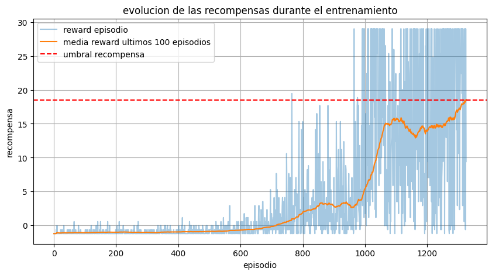

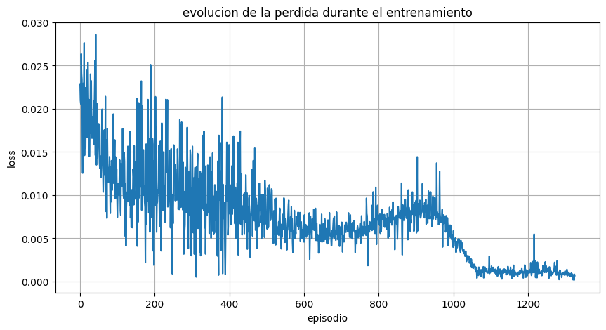

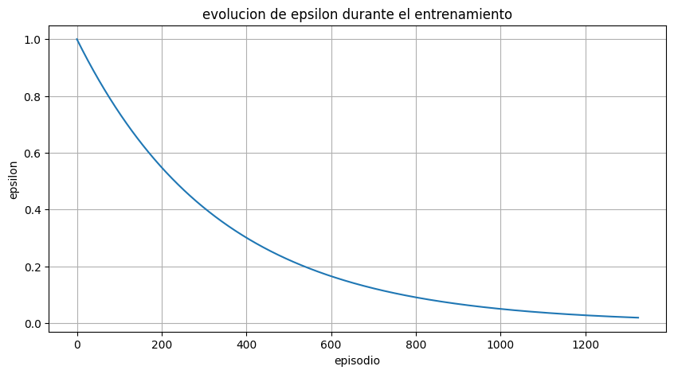

```python
#TODO: Mostrar gráficas
# grafica de recompensas y media movida
plot_rewards(
    agentDDQN.training_rewards,
    agentDDQN.mean_training_rewards,
    REWARD_THRESHOLD
)

# grafica de las perdidas durante el entrenamiento
plot_loss(agentDDQN.loss_values)

# grafica de la evolucion de epsilon
plot_epsilon(agentDDQN.epsilon_evolution)
```

### 4.2 Test del agente en Pong

**Ejercicio 4.4(0.75 ptos):** Cargar el modelo entrenado y evaluar su comportamiento en el entorno `Pong-v0`.

Para ello, realiza las siguientes tareas en este orden:

1. **Visualización de una partida:** Ejecuta una partida completa del agente entrenado en el entorno Pong y muestra por pantalla el resultado final (por ejemplo, puntuación total o número de puntos ganados).
2. **Evaluación cuantitativa:** Ejecuta el agente durante **20 partidas consecutivas** sin renderizar y calcula las métricas de rendimiento:
- Recompensa media obtenida en las 20 partidas → almacénala en la variable `mean_reward_dqn_test`.
3. **Gráfico de resultados:** Representa un gráfico con la suma de recompensas obtenidas en las 20 partidas de test, incluyendo una línea horizontal que indique el umbral de recompensa objetivo (por ejemplo, `REWARD_THRESHOLD = 18`).
4. **Análisis final:** Comenta los resultados obtenidos:
   - ¿Ha alcanzado el agente un rendimiento estable y superior al umbral de recompensa?
   - ¿Muestra el comportamiento esperado en Pong?
   - ¿El modelo mejora al anterior? Justifica la respuesta con base teórica.

[figure not shown]

```
recompensa total partida test double dqn: 29.0
recompensa media test double dqn en 20 episodios: 28.999999999998824
```

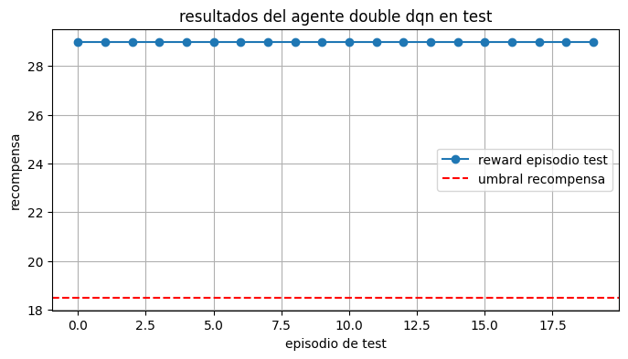

```python
#TODO: Test del agente

# test del agente double dqn

# visualizacion de una partida del agente entrenado
env_test_ddqn = gym.make(
    "SimplePong-v0",
    render_mode="rgb_array",
    width=24,
    height=18,
    paddle_size=4,
    rgb_scale=18,
    max_steps=2000
)

state, _ = env_test_ddqn.reset(seed=42)

fig, ax = plt.subplots(figsize=(5.5, 3.8))
frame = env_test_ddqn.render()
im = ax.imshow(frame, interpolation="nearest")
ax.axis("off")
disp = display(fig, display_id=True)

total_r = 0.0                # recompensa acumulada en este episodio
done = False

while not done:
    # usamos la politica greedy de la red double dqn sin exploracion
    action = net_ddqn.get_action(state, epsilon=0.0)

    next_state, reward, terminated, truncated, info = env_test_ddqn.step(action)
    done = terminated or truncated
    total_r += reward
    state = next_state

    frame = env_test_ddqn.render()
    im.set_data(frame)
    fig.canvas.draw_idle()
    disp.update(fig)
    time.sleep(0.01)

print("recompensa total partida test double dqn:", round(total_r, 2))
env_test_ddqn.close()
plt.close(fig)


# evaluacion cuantitativa en 20 episodios sin render
env_eval_ddqn = gym.make(
    "SimplePong-v0",
    render_mode=None,
    width=24,
    height=18,
    paddle_size=4,
    max_steps=2000
)

n_test_episodes = 20
rewards_test_ddqn = []

for ep in range(n_test_episodes):
    state, _ = env_eval_ddqn.reset()
    done = False
    total_r = 0.0

    while not done:
        # politica greedy sin ruido
        action = net_ddqn.get_action(state, epsilon=0.0)
        next_state, reward, terminated, truncated, info = env_eval_ddqn.step(action)
        done = terminated or truncated
        total_r += reward
        state = next_state

    rewards_test_ddqn.append(total_r)

# recompensa media en test para el agente double dqn
mean_reward_ddqn_test = np.mean(rewards_test_ddqn)
print("recompensa media test double dqn en", n_test_episodes, "episodios:", mean_reward_ddqn_test)

# grafico de las recompensas de test
plt.figure(figsize=(8, 4))
plt.plot(rewards_test_ddqn, marker="o", label="reward episodio test")
plt.axhline(REWARD_THRESHOLD, color="r", linestyle="--", label="umbral recompensa")
plt.xlabel("episodio de test")
plt.ylabel("recompensa")
plt.title("resultados del agente double dqn en test")
plt.legend()
plt.grid(True)
plt.show()

env_eval_ddqn.close()
```

**Fuentes Ejercicio 4:**  
M9 – Deep Q-Networks  
Double Deep Q-Networks (DDQN) - A Quick Intro (with Code) - https://dilithjay.com/blog/ddqn  
Vanilla DQN, Double DQN, and Dueling DQN implemented in PyTorch - https://github.com/dxyang/DQN_pytorch

## 5 Comparación de los resultados (1 pto)

Ahora vamos a comparar los resultados. Si has seguido todas las indicaciones, habrás almacenado métricas bastante interesantes que te permitirán interpretar los resultados obtenidos.

```python
mean_reward_dqn = mean_reward_dqn_test
mean_reward_agentduelingDQN = mean_reward_dueling_test
mean_reward_ddqn = mean_reward_ddqn_test



# Define los datos de la tabla
data = [
    ["DQN", mean_reward_dqn, time_dqn],
    ["Dueling DQN", mean_reward_agentduelingDQN, time_ddqn],
        ["Double DQN", mean_reward_ddqn, time_double_dqn],


]


# Define los encabezados de la tabla
headers = ["Agente", "Media Reward de Entrenamiento", "Media test con 100 Partidas Aleatorias" , "Tiempo entrenamiento."]

# Imprime la tabla
table = tabulate(data, headers, tablefmt="pipe")
print(table)
```

[output not shown]

**Ejercicio (1 pto):**

Comentar los resultados obtenidos. ¿qué agente ha logrado un mejor rendimiento? Si el entorno Pong no transfiriera al agente la información sobre la posición o el movimiento de la pelota, ¿cómo podríamos obtener o estimar esa información? ¿Modificaria los resultados?